# Actualización de los datos de Coronavirus

by [Santiago Mota](https://www.linkedin.com/in/santiagomota/)

2020-05-07

```r
library(readr)
library(dplyr)
library(TSstudio)
library(xml2)
library(rvest)
library(tmap)
```

# Acceso a los datos de Open Data en La Rioja

La base del acceso se hace en https://actualidad.larioja.org/coronavirus/datos

## Evolución

La página de datos abiertos es esta: https://web.larioja.org/dato-abierto/datoabierto?n=opd-452

La estructura html la sacamos copiando el html en local y abriéndolo con notepad++

```html
<div class="col-md-6">
                        <dl>
                            <dt>Fecha de publicación:</dt>
                            <dd>28/04/2020</dd>

                            <dt>Última actualización:</dt>
                            <dd>30/04/2020</dd>

                            <dt>Ámbito temporal</dt>
                            <dd><i class="far fa-calendar-check" aria-hidden="true"></i> 24/02/2020
                                </dd>

                            <dt>Cronología</dt>
                            <dd>Fecha de creación: 28/04/2020 <br>Fecha de actualización de los datos: 30/04/2020</dd>
                        </dl>
                    </div>
```

```r
page_evolucion <- read_html('https://web.larioja.org/dato-abierto/datoabierto?n=opd-452')

# find all nodes with a class of "col_md_6"
col_md_6_evolucion <- html_nodes(page_evolucion, css = '.col-md-6')
col_md_6_evolucion
```

```
## {xml_nodeset (8)}
## [1] <li class="col-md-6"><a href="/participacion"><span class="fas fa-lg fa-u ...
## [2] <li class="col-md-6"><a href="/quejas-y-sugerencias"><span class="fas fa- ...
## [3] <li class="col-md-6"><a href="/suscripciones"><span class="fas fa-lg fa-b ...
## [4] <li class="col-md-6"><a href="/contacto"><span class="fas fa-lg fa-envelo ...
## [5] <li class="col-md-6"><a href="https://www.larioja.org/direcciones-utiles/ ...
## [6] <li class="col-md-6"><a href="https://www.larioja.org/oficina-electronica ...
## [7] <div class="col-md-6">\n                        <dl>\n<dt>Creador</dt>\n  ...
## [8] <div class="col-md-6">\n                        <dl>\n<dt>Fecha de public ...
```

```r
html_children(col_md_6_evolucion[8])
```

```r
class(html_children(col_md_6_evolucion[8]))
```

```r
# La fecha está en col_md_6_evolucion[8]
html_text(html_children(col_md_6_evolucion[8]))
```

```r
class(html_text(html_children(col_md_6_evolucion[8])))
```

```r
json_data <- jsonlite::toJSON(html_text(html_children(col_md_6_evolucion[8])))
json_data
```

```r
html_children(col_md_6_evolucion[8]) %>%
  str_split("\n")
```

```r
html_children(col_md_6_evolucion[8]) %>%
  str_split("\n") %>%
  class()
```

```r
html_children(col_md_6_evolucion[8]) %>%
  str_split("\n") %>%
  unlist()
```

```r
html_text(html_children(col_md_6_evolucion[8])) %>%
  str_split("\n")
```

Esto si vale

```r
fecha_campos_evolucion <- html_children(col_md_6_evolucion[8]) %>%
    html_nodes("dt") %>%
    html_text(trim = TRUE)
fecha_campos_evolucion
```

```
## [1] "Fecha de publicación:" "Última actualización:" "Ámbito temporal"
## [4] "Cronología"
```

```r
fecha_valores_evolucion <- html_children(col_md_6_evolucion[8]) %>%
    html_nodes("dd") %>%
    html_text(trim = TRUE)
fecha_valores_evolucion
```

```
## [1] "28/04/2020"
## [2] "07/05/2020"
## [3] "24/02/2020"
## [4] "Fecha de creación: 28/04/2020 Fecha de actualización de los datos: 07/05/2020"
```

```r
link_evolucion <- 'https://ias1.larioja.org/opendata/download?r=Y2Q9NDUyfGNmPTAz'
```

```r
rioja_evolucion <- read_csv(link_evolucion, locale = locale(date_names = "es"),
                            skip = 1,
                            col_names = c('fecha', 'confirmados_PCR', 'altas', 'fallecidos'))
```

**Revisar esto**

Tienen que coincidir las fechas

```r
rioja_evolucion$fecha <- as.Date(rioja_evolucion$fecha, '%m/%d/%y')
```

Calculamos los acumulados

A la mierda, con un for…

```r
# Valores diarios
rioja_evolucion$acumulado_confirmados <- rioja_evolucion$confirmados_PCR[1]
rioja_evolucion$acumulado_altas       <- rioja_evolucion$altas[1]
rioja_evolucion$acumulado_fallecidos  <- rioja_evolucion$fallecidos[1]

for (i in 2:dim(rioja_evolucion)[1]) {
  rioja_evolucion$acumulado_confirmados[i] <- rioja_evolucion$acumulado_confirmados[i-1] + rioja_evolucion$confirmados_PCR[i]
  rioja_evolucion$acumulado_altas[i]       <- rioja_evolucion$acumulado_altas[i-1] +       rioja_evolucion$altas[i]
  rioja_evolucion$acumulado_fallecidos[i]  <- rioja_evolucion$acumulado_fallecidos[i-1] +  rioja_evolucion$fallecidos[i]
}
```

```r
rioja_evolucion2 <- rioja_evolucion %>%
  arrange(fecha) %>%
  mutate(total_confirmados = confirmados_PCR + lag(total_confirmados))
```

Incorporamos la fecha del dato

```r
rioja_evolucion$fecha_publicacion_evolucion    = as.Date(fecha_valores_evolucion[1], '%d/%m/%Y')
rioja_evolucion$ultima_actualizacion_evolucion = as.Date(fecha_valores_evolucion[2], '%d/%m/%Y')
rioja_evolucion$ambito_temporal_evolucion      = as.Date(fecha_valores_evolucion[3], '%d/%m/%Y')
```

```r
summary(rioja_evolucion)
```

```
##      fecha            confirmados_PCR      altas          fallecidos
##  Min.   :2020-02-24   Min.   :  0.00   Min.   :  0.00   Min.   : 0.000
##  1st Qu.:2020-03-12   1st Qu.: 11.75   1st Qu.:  1.00   1st Qu.: 0.000
##  Median :2020-03-30   Median : 36.50   Median : 31.50   Median : 4.000
##  Mean   :2020-03-30   Mean   : 55.28   Mean   : 33.28   Mean   : 4.681
##  3rd Qu.:2020-04-17   3rd Qu.: 77.50   3rd Qu.: 61.00   3rd Qu.: 8.000
##  Max.   :2020-05-05   Max.   :241.00   Max.   :111.00   Max.   :19.000
##  acumulado_confirmados acumulado_altas  acumulado_fallecidos
##  Min.   :   0.0        Min.   :   0.0   Min.   :  0.0
##  1st Qu.: 283.8        1st Qu.:   3.0   1st Qu.:  3.0
##  Median :1885.0        Median : 532.5   Median : 87.5
##  Mean   :1928.1        Mean   : 863.7   Mean   :133.3
##  3rd Qu.:3596.2        3rd Qu.:1786.8   3rd Qu.:273.2
##  Max.   :3980.0        Max.   :2396.0   Max.   :337.0
##  fecha_publicacion_evolucion ultima_actualizacion_evolucion
##  Min.   :2020-04-28          Min.   :2020-05-07
##  1st Qu.:2020-04-28          1st Qu.:2020-05-07
##  Median :2020-04-28          Median :2020-05-07
##  Mean   :2020-04-28          Mean   :2020-05-07
##  3rd Qu.:2020-04-28          3rd Qu.:2020-05-07
##  Max.   :2020-04-28          Max.   :2020-05-07
##  ambito_temporal_evolucion
##  Min.   :2020-02-24
##  1st Qu.:2020-02-24
##  Median :2020-02-24
##  Mean   :2020-02-24
##  3rd Qu.:2020-02-24
##  Max.   :2020-02-24
```

Guardamos

```r
saveRDS(rioja_evolucion, file = paste0('./data/rioja_evolucion_', Sys.Date(),'.rds'))
```

## Porcentaje de casos, hospitalizados, UCI y fallecidos por grupo de edad

La página de datos abiertos es esta: https://web.larioja.org/dato-abierto/datoabierto?filtros=%7B%22title%22%3A%22coronavirus%2520por%2520grupo%2520de%2520edad%2520y%2520sexo%22%7D&q=&page=1&sort=fecha_publicacion+desc

## Situación de los hospitales de La Rioja

La página de datos abiertos es esta: https://web.larioja.org/dato-abierto/datoabierto?n=opd-461

```r
page_hospitales <- read_html('https://web.larioja.org/dato-abierto/datoabierto?n=opd-461')

# find all nodes with a class of "col_md_6"
col_md_6_hospitales <- html_nodes(page_hospitales, css = '.col-md-6')
col_md_6_hospitales
```

```
## {xml_nodeset (8)}
## [1] <li class="col-md-6"><a href="/participacion"><span class="fas fa-lg fa-u ...
## [2] <li class="col-md-6"><a href="/quejas-y-sugerencias"><span class="fas fa- ...
## [3] <li class="col-md-6"><a href="/suscripciones"><span class="fas fa-lg fa-b ...
## [4] <li class="col-md-6"><a href="/contacto"><span class="fas fa-lg fa-envelo ...
## [5] <li class="col-md-6"><a href="https://www.larioja.org/direcciones-utiles/ ...
## [6] <li class="col-md-6"><a href="https://www.larioja.org/oficina-electronica ...
## [7] <div class="col-md-6">\n                        <dl>\n<dt>Creador</dt>\n  ...
## [8] <div class="col-md-6">\n                        <dl>\n<dt>Fecha de public ...
```

```r
fecha_campos_hospitales <- html_children(col_md_6_hospitales[8]) %>%
    html_nodes("dt") %>%
    html_text(trim = TRUE)
fecha_campos_hospitales
```

```
## [1] "Fecha de publicación:" "Última actualización:" "Ámbito temporal"
## [4] "Cronología"
```

```r
fecha_valores_hospitales <- html_children(col_md_6_hospitales[8]) %>%
    html_nodes("dd") %>%
    html_text(trim = TRUE)
fecha_valores_hospitales
```

```
## [1] "28/04/2020"
## [2] "07/05/2020"
## [3] "24/02/2020"
## [4] "Fecha de creación: 28/04/2020 Fecha de actualización de los datos: 07/05/2020"
```

Ahora bajamos el fichero

```r
link_hospitales <- 'https://ias1.larioja.org/opendata/download?r=Y2Q9NDYxfGNmPTAz'
```

```r
rioja_hospitales <- read_delim(link_hospitales, ",", escape_double = FALSE,
                               na = c("", "NA", "-"), trim_ws = TRUE)
rioja_hospitales <- as.data.frame(rioja_hospitales)
```

```r
names(rioja_hospitales) <- c("hospital", "hospitalizados_total",
                             "hospitalizados_planta", "hospitalizados_uci")
```

```r
sum(rioja_hospitales$hospitalizados_total, na.rm = TRUE)
```

```
## [1] 102
```

Creamos una línea con los totales

```r
rioja_hospitales <- rbind(rioja_hospitales, data.frame(hospital = 'Total',
                                                       hospitalizados_total  = sum(rioja_hospitales$hospitalizados_total, na.rm = TRUE),
                                                       hospitalizados_planta = sum(rioja_hospitales$hospitalizados_planta, na.rm = TRUE),
                                                       hospitalizados_uci    = sum(rioja_hospitales$hospitalizados_uci, na.rm = TRUE)))
```

Incorporamos la fecha del dato

```r
rioja_hospitales$fecha_publicacion_hospitales    = as.Date(fecha_valores_hospitales[1], '%d/%m/%Y')
rioja_hospitales$ultima_actualizacion_hospitales = as.Date(fecha_valores_hospitales[2], '%d/%m/%Y')
rioja_hospitales$ambito_temporal_hospitales      = as.Date(fecha_valores_hospitales[3], '%d/%m/%Y')
```

```r
summary(rioja_hospitales)
```

```
##    hospital         hospitalizados_total hospitalizados_planta
##  Length:5           Min.   :  6.0        Min.   : 6
##  Class :character   1st Qu.: 13.0        1st Qu.:13
##  Mode  :character   Median : 19.0        Median :19
##                     Mean   : 40.8        Mean   :36
##                     3rd Qu.: 64.0        3rd Qu.:52
##                     Max.   :102.0        Max.   :90
##
##  hospitalizados_uci fecha_publicacion_hospitales
##  Min.   :12         Min.   :2020-04-28
##  1st Qu.:12         1st Qu.:2020-04-28
##  Median :12         Median :2020-04-28
##  Mean   :12         Mean   :2020-04-28
##  3rd Qu.:12         3rd Qu.:2020-04-28
##  Max.   :12         Max.   :2020-04-28
##  NA's   :3
##  ultima_actualizacion_hospitales ambito_temporal_hospitales
##  Min.   :2020-05-07              Min.   :2020-02-24
##  1st Qu.:2020-05-07              1st Qu.:2020-02-24
##  Median :2020-05-07              Median :2020-02-24
##  Mean   :2020-05-07              Mean   :2020-02-24
##  3rd Qu.:2020-05-07              3rd Qu.:2020-02-24
##  Max.   :2020-05-07              Max.   :2020-02-24
##
```

**Revisar que cuadra**

```r
# En esta caso es la última línea
diario <- data.frame(hospitalizados_total               = rioja_hospitales$hospitalizados_total[dim(rioja_hospitales)[1]],
                     hospitalizados_planta              = rioja_hospitales$hospitalizados_planta[dim(rioja_hospitales)[1]],
                     hospitalizados_uci                 = rioja_hospitales$hospitalizados_uci[dim(rioja_hospitales)[1]],

                     hospitalizados_total_s_pedro       = rioja_hospitales$hospitalizados_total[rioja_hospitales$hospital == 'Hospital San Pedro'],
                     hospitalizados_planta_s_pedro      = rioja_hospitales$hospitalizados_planta[rioja_hospitales$hospital == 'Hospital San Pedro'],
                     hospitalizados_uci_s_pedro         = rioja_hospitales$hospitalizados_uci[rioja_hospitales$hospital == 'Hospital San Pedro'],

                     hospitalizados_total_la_rioja      = rioja_hospitales$hospitalizados_total[rioja_hospitales$hospital == 'Hospital de La Rioja'],
                     hospitalizados_planta_la_rioja     = rioja_hospitales$hospitalizados_planta[rioja_hospitales$hospital == 'Hospital de La Rioja'],
                     hospitalizados_uci_la_rioja        = rioja_hospitales$hospitalizados_uci[rioja_hospitales$hospital == 'Hospital de La Rioja'],

                     hospitalizados_total_calahorra     = rioja_hospitales$hospitalizados_total[rioja_hospitales$hospital == 'F. H. Calahorra'],
                     hospitalizados_planta_calahorra    = rioja_hospitales$hospitalizados_planta[rioja_hospitales$hospital == 'F. H. Calahorra'],
                     hospitalizados_uci_calahorra       = rioja_hospitales$hospitalizados_uci[rioja_hospitales$hospital == 'F. H. Calahorra'],

                     hospitalizados_total_manzanos      = rioja_hospitales$hospitalizados_total[rioja_hospitales$hospital == 'Los Manzanos'],
                     hospitalizados_planta_manzanos     = rioja_hospitales$hospitalizados_planta[rioja_hospitales$hospital == 'Los Manzanos'],
                     hospitalizados_uci_manzanos        = rioja_hospitales$hospitalizados_uci[rioja_hospitales$hospital == 'Los Manzanos'],

                     fecha_publicacion_hospitales       = as.Date(fecha_valores_hospitales[1], '%d/%m/%Y'),
                     ultima_actualizacion_hospitales    = as.Date(fecha_valores_hospitales[2], '%d/%m/%Y'),
                     ambito_temporal_hospitales         = as.Date(fecha_valores_hospitales[3], '%d/%m/%Y')
                     )
```

Guardamos

```r
saveRDS(rioja_hospitales, file = paste0('./data/rioja_hospitales_', Sys.Date(),'.rds'))
```

Añadimos al diario

```r
resumen_diario <- data.frame(time_stamp = Sys.time())
resumen_diario <- cbind(resumen_diario, diario)
```

## Porcentaje de hospitalizados por grupo de edad y sexo

Porcentaje de hospitalizados por grupo de edad y sexo a a fecha actual

La página de datos abiertos es esta: https://web.larioja.org/dato-abierto/datoabierto?n=opd-453

```r
page_hospitalizados_porcentaje <- read_html('https://web.larioja.org/dato-abierto/datoabierto?n=opd-453')

# find all nodes with a class of "col_md_6"
col_md_6_hospitalizados_porcentaje <- html_nodes(page_hospitalizados_porcentaje, css = '.col-md-6')
col_md_6_hospitalizados_porcentaje
```

```
## {xml_nodeset (8)}
## [1] <li class="col-md-6"><a href="/participacion"><span class="fas fa-lg fa-u ...
## [2] <li class="col-md-6"><a href="/quejas-y-sugerencias"><span class="fas fa- ...
## [3] <li class="col-md-6"><a href="/suscripciones"><span class="fas fa-lg fa-b ...
## [4] <li class="col-md-6"><a href="/contacto"><span class="fas fa-lg fa-envelo ...
## [5] <li class="col-md-6"><a href="https://www.larioja.org/direcciones-utiles/ ...
## [6] <li class="col-md-6"><a href="https://www.larioja.org/oficina-electronica ...
## [7] <div class="col-md-6">\n                        <dl>\n<dt>Creador</dt>\n  ...
## [8] <div class="col-md-6">\n                        <dl>\n<dt>Fecha de public ...
```

```r
fecha_campos_hospitalizados_porcentaje <- html_children(col_md_6_hospitalizados_porcentaje[8]) %>%
    html_nodes("dt") %>%
    html_text(trim = TRUE)
fecha_campos_hospitalizados_porcentaje
```

```
## [1] "Fecha de publicación:" "Última actualización:" "Ámbito temporal"
## [4] "Cronología"
```

```r
fecha_valores_hospitalizados_porcentaje <- html_children(col_md_6_hospitalizados_porcentaje[8]) %>%
    html_nodes("dd") %>%
    html_text(trim = TRUE)
fecha_valores_hospitalizados_porcentaje
```

```
## [1] "28/04/2020"
## [2] "07/05/2020"
## [3] "24/02/2020"
## [4] "Fecha de creación: 28/04/2020 Fecha de actualización de los datos: 07/05/2020"
```

Ahora bajamos el fichero

```r
link_hospitalizados_porcentaje <- 'https://ias1.larioja.org/opendata/download?r=Y2Q9NDUzfGNmPTAz'
```

```r
rioja_hospitalizados_porcentaje <- read_delim(link_hospitalizados_porcentaje, ",", escape_double = FALSE,
                               na = c("", "NA", "-"), trim_ws = TRUE)
rioja_hospitalizados_porcentaje <- as.data.frame(rioja_hospitalizados_porcentaje)
```

```r
names(rioja_hospitalizados_porcentaje) <- c("franja_edad", "hombres",
                             "mujeres", "x4")
```

Borramos x4

```r
rioja_hospitalizados_porcentaje <- rioja_hospitalizados_porcentaje[, 1:3]
```

Incorporamos la fecha del dato

```r
rioja_hospitalizados_porcentaje$fecha_publicacion_hospitalizados_porcentaje    = as.Date(fecha_valores_hospitalizados_porcentaje[1], '%d/%m/%Y')
rioja_hospitalizados_porcentaje$ultima_actualizacion_hospitalizados_porcentaje = as.Date(fecha_valores_hospitalizados_porcentaje[2], '%d/%m/%Y')
rioja_hospitalizados_porcentaje$ambito_temporal_hospitalizados_porcentaje      = as.Date(fecha_valores_hospitalizados_porcentaje[3], '%d/%m/%Y')
```

```r
summary(rioja_hospitalizados_porcentaje)
```

```
##  franja_edad           hombres         mujeres
##  Length:8           Min.   : 0.30   Min.   : 0.700
##  Class :character   1st Qu.: 1.55   1st Qu.: 1.325
##  Mode  :character   Median : 6.35   Median : 5.550
##                     Mean   :12.50   Mean   :12.500
##                     3rd Qu.:15.70   3rd Qu.:10.600
##                     Max.   :51.60   Max.   :63.700
##  fecha_publicacion_hospitalizados_porcentaje
##  Min.   :2020-04-28
##  1st Qu.:2020-04-28
##  Median :2020-04-28
##  Mean   :2020-04-28
##  3rd Qu.:2020-04-28
##  Max.   :2020-04-28
##  ultima_actualizacion_hospitalizados_porcentaje
##  Min.   :2020-05-07
##  1st Qu.:2020-05-07
##  Median :2020-05-07
##  Mean   :2020-05-07
##  3rd Qu.:2020-05-07
##  Max.   :2020-05-07
##  ambito_temporal_hospitalizados_porcentaje
##  Min.   :2020-02-24
##  1st Qu.:2020-02-24
##  Median :2020-02-24
##  Mean   :2020-02-24
##  3rd Qu.:2020-02-24
##  Max.   :2020-02-24
```

```r
str(rioja_hospitalizados_porcentaje)
```

```
## 'data.frame':    8 obs. of  6 variables:
##  $ franja_edad                                   : chr  "0-9 " "10-19 " "20-29 " "30-39 " ...
##  $ hombres                                       : num  0.3 0.5 1.9 4.2 8.5 14.9 18.1 51.6
##  $ mujeres                                       : num  0.7 0.8 1.5 4.1 7 10.1 12.1 63.7
##  $ fecha_publicacion_hospitalizados_porcentaje   : Date, format: "2020-04-28" "2020-04-28" ...
##  $ ultima_actualizacion_hospitalizados_porcentaje: Date, format: "2020-05-07" "2020-05-07" ...
##  $ ambito_temporal_hospitalizados_porcentaje     : Date, format: "2020-02-24" "2020-02-24" ...
```

```r
sum(rioja_hospitalizados_porcentaje$hombres)
```

```
## [1] 100
```

```r
sum(rioja_hospitalizados_porcentaje$mujeres)
```

```
## [1] 100
```

**Revisar que cuadra**

```r
# En esta caso es la última línea
diario <- data.frame(
                     # hospitalizados_hombres_00_09       = rioja_hospitalizados_porcentaje$hombres[rioja_hospitalizados_porcentaje$franja_edad == '0-9 '],
                     # hospitalizados_hombres_10_19       = rioja_hospitalizados_porcentaje$hombres[rioja_hospitalizados_porcentaje$franja_edad == '10-19 '],
                     # hospitalizados_hombres_20_19       = rioja_hospitalizados_porcentaje$hombres[rioja_hospitalizados_porcentaje$franja_edad == '20-29 '],
                     # hospitalizados_hombres_30_19       = rioja_hospitalizados_porcentaje$hombres[rioja_hospitalizados_porcentaje$franja_edad == '30-39 '],
                     # hospitalizados_hombres_40_19       = rioja_hospitalizados_porcentaje$hombres[rioja_hospitalizados_porcentaje$franja_edad == '40-49 '],
                     # hospitalizados_hombres_50_19       = rioja_hospitalizados_porcentaje$hombres[rioja_hospitalizados_porcentaje$franja_edad == '50-59 '],
                     # hospitalizados_hombres_60_19       = rioja_hospitalizados_porcentaje$hombres[rioja_hospitalizados_porcentaje$franja_edad == '60-69 '],
                     # hospitalizados_hombres_70_Mas      = rioja_hospitalizados_porcentaje$hombres[rioja_hospitalizados_porcentaje$franja_edad == '70 y más'],
                     #
                     # hospitalizados_mujeres_00_09       = rioja_hospitalizados_porcentaje$mujeres[rioja_hospitalizados_porcentaje$franja_edad == '0-9 '],
                     # hospitalizados_mujeres_10_19       = rioja_hospitalizados_porcentaje$mujeres[rioja_hospitalizados_porcentaje$franja_edad == '10-19 '],
                     # hospitalizados_mujeres_20_19       = rioja_hospitalizados_porcentaje$mujeres[rioja_hospitalizados_porcentaje$franja_edad == '20-29 '],
                     # hospitalizados_mujeres_30_19       = rioja_hospitalizados_porcentaje$mujeres[rioja_hospitalizados_porcentaje$franja_edad == '30-39 '],
                     # hospitalizados_mujeres_40_19       = rioja_hospitalizados_porcentaje$mujeres[rioja_hospitalizados_porcentaje$franja_edad == '40-49 '],
                     # hospitalizados_mujeres_50_19       = rioja_hospitalizados_porcentaje$mujeres[rioja_hospitalizados_porcentaje$franja_edad == '50-59 '],
                     # hospitalizados_mujeres_60_19       = rioja_hospitalizados_porcentaje$mujeres[rioja_hospitalizados_porcentaje$franja_edad == '60-69 '],
                     # hospitalizados_mujeres_70_Mas      = rioja_hospitalizados_porcentaje$mujeres[rioja_hospitalizados_porcentaje$franja_edad == '70 y más'],

                     hospitalizados_hombres_00_09       = rioja_hospitalizados_porcentaje$hombres[1],
                     hospitalizados_hombres_10_19       = rioja_hospitalizados_porcentaje$hombres[2],
                     hospitalizados_hombres_20_19       = rioja_hospitalizados_porcentaje$hombres[3],
                     hospitalizados_hombres_30_19       = rioja_hospitalizados_porcentaje$hombres[4],
                     hospitalizados_hombres_40_19       = rioja_hospitalizados_porcentaje$hombres[5],
                     hospitalizados_hombres_50_19       = rioja_hospitalizados_porcentaje$hombres[6],
                     hospitalizados_hombres_60_19       = rioja_hospitalizados_porcentaje$hombres[7],
                     hospitalizados_hombres_70_Mas      = rioja_hospitalizados_porcentaje$hombres[8],

                     hospitalizados_mujeres_00_09       = rioja_hospitalizados_porcentaje$mujeres[1],
                     hospitalizados_mujeres_10_19       = rioja_hospitalizados_porcentaje$mujeres[2],
                     hospitalizados_mujeres_20_19       = rioja_hospitalizados_porcentaje$mujeres[3],
                     hospitalizados_mujeres_30_19       = rioja_hospitalizados_porcentaje$mujeres[4],
                     hospitalizados_mujeres_40_19       = rioja_hospitalizados_porcentaje$mujeres[5],
                     hospitalizados_mujeres_50_19       = rioja_hospitalizados_porcentaje$mujeres[6],
                     hospitalizados_mujeres_60_19       = rioja_hospitalizados_porcentaje$mujeres[7],
                     hospitalizados_mujeres_70_Mas      = rioja_hospitalizados_porcentaje$mujeres[8],


                     fecha_publicacion_hospitalizados_porcentaje       = as.Date(fecha_valores_hospitalizados_porcentaje[1], '%d/%m/%Y'),
                     ultima_actualizacion_hospitalizados_porcentaje    = as.Date(fecha_valores_hospitalizados_porcentaje[2], '%d/%m/%Y'),
                     ambito_temporal_hospitalizados_porcentaje         = as.Date(fecha_valores_hospitalizados_porcentaje[3], '%d/%m/%Y')
                     )
```

Guardamos

```r
saveRDS(rioja_hospitalizados_porcentaje, file = paste0('./data/rioja_hospitalizados_porcentaje_', Sys.Date(),'.rds'))
```

Añadimos al diario

```r
# resumen_diario <- data.frame(time_stamp = Sys.time())
resumen_diario <- cbind(resumen_diario, diario)
```

## Porcentaje de hospitalizados en UCI por grupo de edad y sexo

Porcentaje de hospitalizados en UCI por grupo de edad y sexo a fecha actual

La página de datos abiertos es esta: https://web.larioja.org/dato-abierto/datoabierto?n=opd-454

```r
page_uci_porcentaje <- read_html('https://web.larioja.org/dato-abierto/datoabierto?n=opd-454')

# find all nodes with a class of "col_md_6"
col_md_6_uci_porcentaje <- html_nodes(page_uci_porcentaje, css = '.col-md-6')
col_md_6_uci_porcentaje
```

```
## {xml_nodeset (8)}
## [1] <li class="col-md-6"><a href="/participacion"><span class="fas fa-lg fa-u ...
## [2] <li class="col-md-6"><a href="/quejas-y-sugerencias"><span class="fas fa- ...
## [3] <li class="col-md-6"><a href="/suscripciones"><span class="fas fa-lg fa-b ...
## [4] <li class="col-md-6"><a href="/contacto"><span class="fas fa-lg fa-envelo ...
## [5] <li class="col-md-6"><a href="https://www.larioja.org/direcciones-utiles/ ...
## [6] <li class="col-md-6"><a href="https://www.larioja.org/oficina-electronica ...
## [7] <div class="col-md-6">\n                        <dl>\n<dt>Creador</dt>\n  ...
## [8] <div class="col-md-6">\n                        <dl>\n<dt>Fecha de public ...
```

```r
fecha_campos_uci_porcentaje <- html_children(col_md_6_uci_porcentaje[8]) %>%
    html_nodes("dt") %>%
    html_text(trim = TRUE)
fecha_campos_uci_porcentaje
```

```
## [1] "Fecha de publicación:" "Última actualización:" "Ámbito temporal"
## [4] "Cronología"
```

```r
fecha_valores_uci_porcentaje <- html_children(col_md_6_uci_porcentaje[8]) %>%
    html_nodes("dd") %>%
    html_text(trim = TRUE)
fecha_valores_uci_porcentaje
```

```
## [1] "28/04/2020"
## [2] "07/05/2020"
## [3] "24/02/2020"
## [4] "Fecha de creación: 28/04/2020 Fecha de actualización de los datos: 07/05/2020"
```

Ahora bajamos el fichero

```r
link_uci_porcentaje <- 'https://ias1.larioja.org/opendata/download?r=Y2Q9NDU0fGNmPTAz'
```

```r
rioja_uci_porcentaje <- read_delim(link_uci_porcentaje, ",", escape_double = FALSE,
                               na = c("", "NA", "-"), trim_ws = TRUE)
rioja_uci_porcentaje <- as.data.frame(rioja_uci_porcentaje)
```

```r
names(rioja_uci_porcentaje) <- c("franja_edad", "hombres",
                             "mujeres", "x4")
```

Borramos x4

```r
rioja_uci_porcentaje <- rioja_uci_porcentaje[, 1:3]
```

Incorporamos la fecha del dato

```r
rioja_uci_porcentaje$fecha_publicacion_uci_porcentaje    = as.Date(fecha_valores_uci_porcentaje[1], '%d/%m/%Y')
rioja_uci_porcentaje$ultima_actualizacion_uci_porcentaje = as.Date(fecha_valores_uci_porcentaje[2], '%d/%m/%Y')
rioja_uci_porcentaje$ambito_temporal_uci_porcentaje      = as.Date(fecha_valores_uci_porcentaje[3], '%d/%m/%Y')
```

```r
summary(rioja_uci_porcentaje)
```

```
##  franja_edad           hombres         mujeres
##  Length:8           Min.   : 0.00   Min.   : 0.00
##  Class :character   1st Qu.: 1.50   1st Qu.: 0.00
##  Mode  :character   Median : 3.05   Median : 4.80
##                     Mean   :12.49   Mean   :12.51
##                     3rd Qu.:26.02   3rd Qu.:23.80
##                     Max.   :36.70   Max.   :42.90
##  fecha_publicacion_uci_porcentaje ultima_actualizacion_uci_porcentaje
##  Min.   :2020-04-28               Min.   :2020-05-07
##  1st Qu.:2020-04-28               1st Qu.:2020-05-07
##  Median :2020-04-28               Median :2020-05-07
##  Mean   :2020-04-28               Mean   :2020-05-07
##  3rd Qu.:2020-04-28               3rd Qu.:2020-05-07
##  Max.   :2020-04-28               Max.   :2020-05-07
##  ambito_temporal_uci_porcentaje
##  Min.   :2020-02-24
##  1st Qu.:2020-02-24
##  Median :2020-02-24
##  Mean   :2020-02-24
##  3rd Qu.:2020-02-24
##  Max.   :2020-02-24
```

```r
str(rioja_uci_porcentaje)
```

```
## 'data.frame':    8 obs. of  6 variables:
##  $ franja_edad                        : chr  "0-9 " "10-19 " "20-29 " "30-39 " ...
##  $ hombres                            : num  2 0 0 2 4.1 24.5 36.7 30.6
##  $ mujeres                            : num  0 0 0 4.8 4.8 23.8 23.8 42.9
##  $ fecha_publicacion_uci_porcentaje   : Date, format: "2020-04-28" "2020-04-28" ...
##  $ ultima_actualizacion_uci_porcentaje: Date, format: "2020-05-07" "2020-05-07" ...
##  $ ambito_temporal_uci_porcentaje     : Date, format: "2020-02-24" "2020-02-24" ...
```

```r
sum(rioja_uci_porcentaje$hombres)
```

```
## [1] 99.9
```

```r
sum(rioja_uci_porcentaje$mujeres)
```

```
## [1] 100.1
```

**Revisar que cuadra**

```r
# En esta caso es la última línea
diario <- data.frame(
                     # uci_hombres_00_09       = rioja_uci_porcentaje$hombres[rioja_uci_porcentaje$franja_edad == '0-9 '],
                     # uci_hombres_10_19       = rioja_uci_porcentaje$hombres[rioja_uci_porcentaje$franja_edad == '10-19 '],
                     # uci_hombres_20_19       = rioja_uci_porcentaje$hombres[rioja_uci_porcentaje$franja_edad == '20-29 '],
                     # uci_hombres_30_19       = rioja_uci_porcentaje$hombres[rioja_uci_porcentaje$franja_edad == '30-39 '],
                     # uci_hombres_40_19       = rioja_uci_porcentaje$hombres[rioja_uci_porcentaje$franja_edad == '40-49 '],
                     # uci_hombres_50_19       = rioja_uci_porcentaje$hombres[rioja_uci_porcentaje$franja_edad == '50-59 '],
                     # uci_hombres_60_19       = rioja_uci_porcentaje$hombres[rioja_uci_porcentaje$franja_edad == '60-69 '],
                     # uci_hombres_70_Mas      = rioja_uci_porcentaje$hombres[rioja_uci_porcentaje$franja_edad == '70 y más'],
                     #
                     # uci_mujeres_00_09       = rioja_uci_porcentaje$mujeres[rioja_uci_porcentaje$franja_edad == '0-9 '],
                     # uci_mujeres_10_19       = rioja_uci_porcentaje$mujeres[rioja_uci_porcentaje$franja_edad == '10-19 '],
                     # uci_mujeres_20_19       = rioja_uci_porcentaje$mujeres[rioja_uci_porcentaje$franja_edad == '20-29 '],
                     # uci_mujeres_30_19       = rioja_uci_porcentaje$mujeres[rioja_uci_porcentaje$franja_edad == '30-39 '],
                     # uci_mujeres_40_19       = rioja_uci_porcentaje$mujeres[rioja_uci_porcentaje$franja_edad == '40-49 '],
                     # uci_mujeres_50_19       = rioja_uci_porcentaje$mujeres[rioja_uci_porcentaje$franja_edad == '50-59 '],
                     # uci_mujeres_60_19       = rioja_uci_porcentaje$mujeres[rioja_uci_porcentaje$franja_edad == '60-69 '],
                     # uci_mujeres_70_Mas      = rioja_uci_porcentaje$mujeres[rioja_uci_porcentaje$franja_edad == '70 y más'],

                     uci_hombres_00_09       = rioja_uci_porcentaje$hombres[1],
                     uci_hombres_10_19       = rioja_uci_porcentaje$hombres[2],
                     uci_hombres_20_19       = rioja_uci_porcentaje$hombres[3],
                     uci_hombres_30_19       = rioja_uci_porcentaje$hombres[4],
                     uci_hombres_40_19       = rioja_uci_porcentaje$hombres[5],
                     uci_hombres_50_19       = rioja_uci_porcentaje$hombres[6],
                     uci_hombres_60_19       = rioja_uci_porcentaje$hombres[7],
                     uci_hombres_70_Mas      = rioja_uci_porcentaje$hombres[8],

                     uci_mujeres_00_09       = rioja_uci_porcentaje$mujeres[1],
                     uci_mujeres_10_19       = rioja_uci_porcentaje$mujeres[2],
                     uci_mujeres_20_19       = rioja_uci_porcentaje$mujeres[3],
                     uci_mujeres_30_19       = rioja_uci_porcentaje$mujeres[4],
                     uci_mujeres_40_19       = rioja_uci_porcentaje$mujeres[5],
                     uci_mujeres_50_19       = rioja_uci_porcentaje$mujeres[6],
                     uci_mujeres_60_19       = rioja_uci_porcentaje$mujeres[7],
                     uci_mujeres_70_Mas      = rioja_uci_porcentaje$mujeres[8],


                     fecha_publicacion_uci_porcentaje       = as.Date(fecha_valores_uci_porcentaje[1], '%d/%m/%Y'),
                     ultima_actualizacion_uci_porcentaje    = as.Date(fecha_valores_uci_porcentaje[2], '%d/%m/%Y'),
                     ambito_temporal_uci_porcentaje         = as.Date(fecha_valores_uci_porcentaje[3], '%d/%m/%Y')
                     )
```

Guardamos

```r
saveRDS(rioja_uci_porcentaje, file = paste0('./data/rioja_uci_porcentaje_', Sys.Date(),'.rds'))
```

Añadimos al diario

```r
# resumen_diario <- data.frame(time_stamp = Sys.time())
resumen_diario <- cbind(resumen_diario, diario)
```

## Porcentaje de fallecidos por grupo de edad y sexo

Porcentaje de fallecidos por grupo de edad y sexo a fecha actual

La página de datos abiertos es esta: https://web.larioja.org/dato-abierto/datoabierto?n=opd-455

```r
page_fallecidos_porcentaje <- read_html('https://web.larioja.org/dato-abierto/datoabierto?n=opd-455')

# find all nodes with a class of "col_md_6"
col_md_6_fallecidos_porcentaje <- html_nodes(page_fallecidos_porcentaje, css = '.col-md-6')
col_md_6_fallecidos_porcentaje
```

```
## {xml_nodeset (8)}
## [1] <li class="col-md-6"><a href="/participacion"><span class="fas fa-lg fa-u ...
## [2] <li class="col-md-6"><a href="/quejas-y-sugerencias"><span class="fas fa- ...
## [3] <li class="col-md-6"><a href="/suscripciones"><span class="fas fa-lg fa-b ...
## [4] <li class="col-md-6"><a href="/contacto"><span class="fas fa-lg fa-envelo ...
## [5] <li class="col-md-6"><a href="https://www.larioja.org/direcciones-utiles/ ...
## [6] <li class="col-md-6"><a href="https://www.larioja.org/oficina-electronica ...
## [7] <div class="col-md-6">\n                        <dl>\n<dt>Creador</dt>\n  ...
## [8] <div class="col-md-6">\n                        <dl>\n<dt>Fecha de public ...
```

```r
fecha_campos_fallecidos_porcentaje <- html_children(col_md_6_fallecidos_porcentaje[8]) %>%
    html_nodes("dt") %>%
    html_text(trim = TRUE)
fecha_campos_fallecidos_porcentaje
```

```
## [1] "Fecha de publicación:" "Última actualización:" "Ámbito temporal"
## [4] "Cronología"
```

```r
fecha_valores_fallecidos_porcentaje <- html_children(col_md_6_fallecidos_porcentaje[8]) %>%
    html_nodes("dd") %>%
    html_text(trim = TRUE)
fecha_valores_fallecidos_porcentaje
```

```
## [1] "28/04/2020"
## [2] "07/05/2020"
## [3] "24/02/2020"
## [4] "Fecha de creación: 28/04/2020 Fecha de actualización de los datos: 07/05/2020"
```

Ahora bajamos el fichero

```r
link_fallecidos_porcentaje <- 'https://ias1.larioja.org/opendata/download?r=Y2Q9NDU1fGNmPTAz'
```

```r
rioja_fallecidos_porcentaje <- read_delim(link_fallecidos_porcentaje, ",", escape_double = FALSE,
                               na = c("", "NA", "-"), trim_ws = TRUE)
rioja_fallecidos_porcentaje <- as.data.frame(rioja_fallecidos_porcentaje)
```

```r
names(rioja_fallecidos_porcentaje) <- c("franja_edad", "hombres",
                             "mujeres", "x4")
```

Borramos x4

```r
rioja_fallecidos_porcentaje <- rioja_fallecidos_porcentaje[, 1:3]
```

Incorporamos la fecha del dato

```r
rioja_fallecidos_porcentaje$fecha_publicacion_fallecidos_porcentaje    = as.Date(fecha_valores_fallecidos_porcentaje[1], '%d/%m/%Y')
rioja_fallecidos_porcentaje$ultima_actualizacion_fallecidos_porcentaje = as.Date(fecha_valores_fallecidos_porcentaje[2], '%d/%m/%Y')
rioja_fallecidos_porcentaje$ambito_temporal_fallecidos_porcentaje      = as.Date(fecha_valores_fallecidos_porcentaje[3], '%d/%m/%Y')
```

```r
summary(rioja_fallecidos_porcentaje)
```

```
##  franja_edad           hombres         mujeres
##  Length:8           Min.   : 0.00   Min.   : 0.000
##  Class :character   1st Qu.: 0.00   1st Qu.: 0.000
##  Mode  :character   Median : 1.20   Median : 0.300
##                     Mean   :12.50   Mean   :12.500
##                     3rd Qu.: 5.25   3rd Qu.: 1.775
##                     Max.   :82.80   Max.   :94.700
##  fecha_publicacion_fallecidos_porcentaje
##  Min.   :2020-04-28
##  1st Qu.:2020-04-28
##  Median :2020-04-28
##  Mean   :2020-04-28
##  3rd Qu.:2020-04-28
##  Max.   :2020-04-28
##  ultima_actualizacion_fallecidos_porcentaje
##  Min.   :2020-05-07
##  1st Qu.:2020-05-07
##  Median :2020-05-07
##  Mean   :2020-05-07
##  3rd Qu.:2020-05-07
##  Max.   :2020-05-07
##  ambito_temporal_fallecidos_porcentaje
##  Min.   :2020-02-24
##  1st Qu.:2020-02-24
##  Median :2020-02-24
##  Mean   :2020-02-24
##  3rd Qu.:2020-02-24
##  Max.   :2020-02-24
```

```r
str(rioja_fallecidos_porcentaje)
```

```
## 'data.frame':    8 obs. of  6 variables:
##  $ franja_edad                               : chr  "0-9 " "10-19 " "20-29 " "30-39 " ...
##  $ hombres                                   : num  0 0 0 0.6 1.8 3.1 11.7 82.8
##  $ mujeres                                   : num  0 0 0 0.6 1.2 0 3.5 94.7
##  $ fecha_publicacion_fallecidos_porcentaje   : Date, format: "2020-04-28" "2020-04-28" ...
##  $ ultima_actualizacion_fallecidos_porcentaje: Date, format: "2020-05-07" "2020-05-07" ...
##  $ ambito_temporal_fallecidos_porcentaje     : Date, format: "2020-02-24" "2020-02-24" ...
```

```r
sum(rioja_fallecidos_porcentaje$hombres)
```

```
## [1] 100
```

```r
sum(rioja_fallecidos_porcentaje$mujeres)
```

```
## [1] 100
```

**Revisar que cuadra**

```r
# En esta caso es la última línea
diario <- data.frame(
                     # fallecidos_hombres_00_09       = rioja_fallecidos_porcentaje$hombres[rioja_fallecidos_porcentaje$franja_edad == '0-9 '],
                     # fallecidos_hombres_10_19       = rioja_fallecidos_porcentaje$hombres[rioja_fallecidos_porcentaje$franja_edad == '10-19 '],
                     # fallecidos_hombres_20_19       = rioja_fallecidos_porcentaje$hombres[rioja_fallecidos_porcentaje$franja_edad == '20-29 '],
                     # fallecidos_hombres_30_19       = rioja_fallecidos_porcentaje$hombres[rioja_fallecidos_porcentaje$franja_edad == '30-39 '],
                     # fallecidos_hombres_40_19       = rioja_fallecidos_porcentaje$hombres[rioja_fallecidos_porcentaje$franja_edad == '40-49 '],
                     # fallecidos_hombres_50_19       = rioja_fallecidos_porcentaje$hombres[rioja_fallecidos_porcentaje$franja_edad == '50-59 '],
                     # fallecidos_hombres_60_19       = rioja_fallecidos_porcentaje$hombres[rioja_fallecidos_porcentaje$franja_edad == '60-69 '],
                     # fallecidos_hombres_70_Mas      = rioja_fallecidos_porcentaje$hombres[rioja_fallecidos_porcentaje$franja_edad == '70 y más'],
                     #
                     # fallecidos_mujeres_00_09       = rioja_fallecidos_porcentaje$mujeres[rioja_fallecidos_porcentaje$franja_edad == '0-9 '],
                     # fallecidos_mujeres_10_19       = rioja_fallecidos_porcentaje$mujeres[rioja_fallecidos_porcentaje$franja_edad == '10-19 '],
                     # fallecidos_mujeres_20_19       = rioja_fallecidos_porcentaje$mujeres[rioja_fallecidos_porcentaje$franja_edad == '20-29 '],
                     # fallecidos_mujeres_30_19       = rioja_fallecidos_porcentaje$mujeres[rioja_fallecidos_porcentaje$franja_edad == '30-39 '],
                     # fallecidos_mujeres_40_19       = rioja_fallecidos_porcentaje$mujeres[rioja_fallecidos_porcentaje$franja_edad == '40-49 '],
                     # fallecidos_mujeres_50_19       = rioja_fallecidos_porcentaje$mujeres[rioja_fallecidos_porcentaje$franja_edad == '50-59 '],
                     # fallecidos_mujeres_60_19       = rioja_fallecidos_porcentaje$mujeres[rioja_fallecidos_porcentaje$franja_edad == '60-69 '],
                     # fallecidos_mujeres_70_Mas      = rioja_fallecidos_porcentaje$mujeres[rioja_fallecidos_porcentaje$franja_edad == '70 y más'],

                     fallecidos_hombres_00_09       = rioja_fallecidos_porcentaje$hombres[1],
                     fallecidos_hombres_10_19       = rioja_fallecidos_porcentaje$hombres[2],
                     fallecidos_hombres_20_19       = rioja_fallecidos_porcentaje$hombres[3],
                     fallecidos_hombres_30_19       = rioja_fallecidos_porcentaje$hombres[4],
                     fallecidos_hombres_40_19       = rioja_fallecidos_porcentaje$hombres[5],
                     fallecidos_hombres_50_19       = rioja_fallecidos_porcentaje$hombres[6],
                     fallecidos_hombres_60_19       = rioja_fallecidos_porcentaje$hombres[7],
                     fallecidos_hombres_70_Mas      = rioja_fallecidos_porcentaje$hombres[8],

                     fallecidos_mujeres_00_09       = rioja_fallecidos_porcentaje$mujeres[1],
                     fallecidos_mujeres_10_19       = rioja_fallecidos_porcentaje$mujeres[2],
                     fallecidos_mujeres_20_19       = rioja_fallecidos_porcentaje$mujeres[3],
                     fallecidos_mujeres_30_19       = rioja_fallecidos_porcentaje$mujeres[4],
                     fallecidos_mujeres_40_19       = rioja_fallecidos_porcentaje$mujeres[5],
                     fallecidos_mujeres_50_19       = rioja_fallecidos_porcentaje$mujeres[6],
                     fallecidos_mujeres_60_19       = rioja_fallecidos_porcentaje$mujeres[7],
                     fallecidos_mujeres_70_Mas      = rioja_fallecidos_porcentaje$mujeres[8],


                     fecha_publicacion_fallecidos_porcentaje       = as.Date(fecha_valores_fallecidos_porcentaje[1], '%d/%m/%Y'),
                     ultima_actualizacion_fallecidos_porcentaje    = as.Date(fecha_valores_fallecidos_porcentaje[2], '%d/%m/%Y'),
                     ambito_temporal_fallecidos_porcentaje         = as.Date(fecha_valores_fallecidos_porcentaje[3], '%d/%m/%Y')
                     )
```

Guardamos

```r
saveRDS(rioja_fallecidos_porcentaje, file = paste0('./data/rioja_fallecidos_porcentaje_', Sys.Date(),'.rds'))
```

Añadimos al diario

```r
# resumen_diario <- data.frame(time_stamp = Sys.time())
resumen_diario <- cbind(resumen_diario, diario)
```

## Porcentaje de casos por grupos de edad

Porcentaje de casos por grupo de edad y sexo a fecha actual

La página de datos abiertos es esta: https://web.larioja.org/dato-abierto/datoabierto?n=opd-456

```r
page_casos_porcentaje <- read_html('https://web.larioja.org/dato-abierto/datoabierto?n=opd-456')

# find all nodes with a class of "col_md_6"
col_md_6_casos_porcentaje <- html_nodes(page_casos_porcentaje, css = '.col-md-6')
col_md_6_casos_porcentaje
```

```
## {xml_nodeset (8)}
## [1] <li class="col-md-6"><a href="/participacion"><span class="fas fa-lg fa-u ...
## [2] <li class="col-md-6"><a href="/quejas-y-sugerencias"><span class="fas fa- ...
## [3] <li class="col-md-6"><a href="/suscripciones"><span class="fas fa-lg fa-b ...
## [4] <li class="col-md-6"><a href="/contacto"><span class="fas fa-lg fa-envelo ...
## [5] <li class="col-md-6"><a href="https://www.larioja.org/direcciones-utiles/ ...
## [6] <li class="col-md-6"><a href="https://www.larioja.org/oficina-electronica ...
## [7] <div class="col-md-6">\n                        <dl>\n<dt>Creador</dt>\n  ...
## [8] <div class="col-md-6">\n                        <dl>\n<dt>Fecha de public ...
```

```r
fecha_campos_casos_porcentaje <- html_children(col_md_6_casos_porcentaje[8]) %>%
    html_nodes("dt") %>%
    html_text(trim = TRUE)
fecha_campos_casos_porcentaje
```

```
## [1] "Fecha de publicación:" "Última actualización:" "Ámbito temporal"
## [4] "Cronología"
```

```r
fecha_valores_casos_porcentaje <- html_children(col_md_6_casos_porcentaje[8]) %>%
    html_nodes("dd") %>%
    html_text(trim = TRUE)
fecha_valores_casos_porcentaje
```

```
## [1] "28/04/2020"
## [2] "07/05/2020"
## [3] "24/02/2020"
## [4] "Fecha de creación: 28/04/2020 Fecha de actualización de los datos: 07/05/2020"
```

Ahora bajamos el fichero

```r
link_casos_porcentaje <- 'https://ias1.larioja.org/opendata/download?r=Y2Q9NDU2fGNmPTAz'
```

```r
rioja_casos_porcentaje <- read_delim(link_casos_porcentaje, ",", escape_double = FALSE,
                               na = c("", "NA", "-"), trim_ws = TRUE)
rioja_casos_porcentaje <- as.data.frame(rioja_casos_porcentaje)
```

```r
names(rioja_casos_porcentaje) <- c("franja_edad", "hombres",
                             "mujeres", "x4")
```

Borramos x4

```r
rioja_casos_porcentaje <- rioja_casos_porcentaje[, 1:3]
```

Incorporamos la fecha del dato

```r
rioja_casos_porcentaje$fecha_publicacion_casos_porcentaje    = as.Date(fecha_valores_casos_porcentaje[1], '%d/%m/%Y')
rioja_casos_porcentaje$ultima_actualizacion_casos_porcentaje = as.Date(fecha_valores_casos_porcentaje[2], '%d/%m/%Y')
rioja_casos_porcentaje$ambito_temporal_casos_porcentaje      = as.Date(fecha_valores_casos_porcentaje[3], '%d/%m/%Y')
```

```r
summary(rioja_casos_porcentaje)
```

```
##  franja_edad           hombres          mujeres
##  Length:8           Min.   : 0.700   Min.   : 0.70
##  Class :character   1st Qu.: 3.975   1st Qu.: 5.05
##  Mode  :character   Median :11.250   Median :11.15
##                     Mean   :12.500   Mean   :12.49
##                     3rd Qu.:16.125   3rd Qu.:16.02
##                     Max.   :37.600   Max.   :36.60
##  fecha_publicacion_casos_porcentaje ultima_actualizacion_casos_porcentaje
##  Min.   :2020-04-28                 Min.   :2020-05-07
##  1st Qu.:2020-04-28                 1st Qu.:2020-05-07
##  Median :2020-04-28                 Median :2020-05-07
##  Mean   :2020-04-28                 Mean   :2020-05-07
##  3rd Qu.:2020-04-28                 3rd Qu.:2020-05-07
##  Max.   :2020-04-28                 Max.   :2020-05-07
##  ambito_temporal_casos_porcentaje
##  Min.   :2020-02-24
##  1st Qu.:2020-02-24
##  Median :2020-02-24
##  Mean   :2020-02-24
##  3rd Qu.:2020-02-24
##  Max.   :2020-02-24
```

```r
str(rioja_casos_porcentaje)
```

```
## 'data.frame':    8 obs. of  6 variables:
##  $ franja_edad                          : chr  "0-9 " "10-19 " "20-29 " "30-39 " ...
##  $ hombres                              : num  0.7 1.2 4.9 9.5 13 17.4 15.7 37.6
##  $ mujeres                              : num  0.7 1.3 6.3 10.9 15.7 17 11.4 36.6
##  $ fecha_publicacion_casos_porcentaje   : Date, format: "2020-04-28" "2020-04-28" ...
##  $ ultima_actualizacion_casos_porcentaje: Date, format: "2020-05-07" "2020-05-07" ...
##  $ ambito_temporal_casos_porcentaje     : Date, format: "2020-02-24" "2020-02-24" ...
```

```r
sum(rioja_casos_porcentaje$hombres)
```

```
## [1] 100
```

```r
sum(rioja_casos_porcentaje$mujeres)
```

```
## [1] 99.9
```

**Revisar que cuadra**

```r
# En esta caso es la última línea
diario <- data.frame(
                     # casos_hombres_00_09       = rioja_casos_porcentaje$hombres[rioja_casos_porcentaje$franja_edad == '0-9 '],
                     # casos_hombres_10_19       = rioja_casos_porcentaje$hombres[rioja_casos_porcentaje$franja_edad == '10-19 '],
                     # casos_hombres_20_19       = rioja_casos_porcentaje$hombres[rioja_casos_porcentaje$franja_edad == '20-29 '],
                     # casos_hombres_30_19       = rioja_casos_porcentaje$hombres[rioja_casos_porcentaje$franja_edad == '30-39 '],
                     # casos_hombres_40_19       = rioja_casos_porcentaje$hombres[rioja_casos_porcentaje$franja_edad == '40-49 '],
                     # casos_hombres_50_19       = rioja_casos_porcentaje$hombres[rioja_casos_porcentaje$franja_edad == '50-59 '],
                     # casos_hombres_60_19       = rioja_casos_porcentaje$hombres[rioja_casos_porcentaje$franja_edad == '60-69 '],
                     # casos_hombres_70_Mas      = rioja_casos_porcentaje$hombres[rioja_casos_porcentaje$franja_edad == '70 y más'],
                     #
                     # casos_mujeres_00_09       = rioja_casos_porcentaje$mujeres[rioja_casos_porcentaje$franja_edad == '0-9 '],
                     # casos_mujeres_10_19       = rioja_casos_porcentaje$mujeres[rioja_casos_porcentaje$franja_edad == '10-19 '],
                     # casos_mujeres_20_19       = rioja_casos_porcentaje$mujeres[rioja_casos_porcentaje$franja_edad == '20-29 '],
                     # casos_mujeres_30_19       = rioja_casos_porcentaje$mujeres[rioja_casos_porcentaje$franja_edad == '30-39 '],
                     # casos_mujeres_40_19       = rioja_casos_porcentaje$mujeres[rioja_casos_porcentaje$franja_edad == '40-49 '],
                     # casos_mujeres_50_19       = rioja_casos_porcentaje$mujeres[rioja_casos_porcentaje$franja_edad == '50-59 '],
                     # casos_mujeres_60_19       = rioja_casos_porcentaje$mujeres[rioja_casos_porcentaje$franja_edad == '60-69 '],
                     # casos_mujeres_70_Mas      = rioja_casos_porcentaje$mujeres[rioja_casos_porcentaje$franja_edad == '70 y más'],

                     casos_hombres_00_09       = rioja_casos_porcentaje$hombres[1],
                     casos_hombres_10_19       = rioja_casos_porcentaje$hombres[2],
                     casos_hombres_20_19       = rioja_casos_porcentaje$hombres[3],
                     casos_hombres_30_19       = rioja_casos_porcentaje$hombres[4],
                     casos_hombres_40_19       = rioja_casos_porcentaje$hombres[5],
                     casos_hombres_50_19       = rioja_casos_porcentaje$hombres[6],
                     casos_hombres_60_19       = rioja_casos_porcentaje$hombres[7],
                     casos_hombres_70_Mas      = rioja_casos_porcentaje$hombres[8],

                     casos_mujeres_00_09       = rioja_casos_porcentaje$mujeres[1],
                     casos_mujeres_10_19       = rioja_casos_porcentaje$mujeres[2],
                     casos_mujeres_20_19       = rioja_casos_porcentaje$mujeres[3],
                     casos_mujeres_30_19       = rioja_casos_porcentaje$mujeres[4],
                     casos_mujeres_40_19       = rioja_casos_porcentaje$mujeres[5],
                     casos_mujeres_50_19       = rioja_casos_porcentaje$mujeres[6],
                     casos_mujeres_60_19       = rioja_casos_porcentaje$mujeres[7],
                     casos_mujeres_70_Mas      = rioja_casos_porcentaje$mujeres[8],


                     fecha_publicacion_casos_porcentaje       = as.Date(fecha_valores_casos_porcentaje[1], '%d/%m/%Y'),
                     ultima_actualizacion_casos_porcentaje    = as.Date(fecha_valores_casos_porcentaje[2], '%d/%m/%Y'),
                     ambito_temporal_casos_porcentaje         = as.Date(fecha_valores_casos_porcentaje[3], '%d/%m/%Y')
                     )
```

Guardamos

```r
saveRDS(rioja_casos_porcentaje, file = paste0('./data/rioja_casos_porcentaje_', Sys.Date(),'.rds'))
```

Añadimos al diario

```r
# resumen_diario <- data.frame(time_stamp = Sys.time())
resumen_diario <- cbind(resumen_diario, diario)
```

# Pendientes

## Datos globales

Datos globales de la pandemia de coronavirus: tasa de letalidad; tasa de hospitalización (casos activos y casos acumulados); y porcentaje de altas acumuladas

La página de datos abiertos es esta: https://web.larioja.org/dato-abierto/datoabierto?n=opd-459

## Pruebas realizadas en La Rioja

Pruebas realizadas en La Rioja (PCR y pruebas rápidas de anticuerpos)

La página de datos abiertos es esta: https://web.larioja.org/dato-abierto/datoabierto?n=opd-462

```r
page_pruebas <- read_html('https://web.larioja.org/dato-abierto/datoabierto?n=opd-462')

# find all nodes with a class of "col_md_6"
col_md_6_pruebas <- html_nodes(page_pruebas, css = '.col-md-6')
col_md_6_pruebas
```

```
## {xml_nodeset (8)}
## [1] <li class="col-md-6"><a href="/participacion"><span class="fas fa-lg fa-u ...
## [2] <li class="col-md-6"><a href="/quejas-y-sugerencias"><span class="fas fa- ...
## [3] <li class="col-md-6"><a href="/suscripciones"><span class="fas fa-lg fa-b ...
## [4] <li class="col-md-6"><a href="/contacto"><span class="fas fa-lg fa-envelo ...
## [5] <li class="col-md-6"><a href="https://www.larioja.org/direcciones-utiles/ ...
## [6] <li class="col-md-6"><a href="https://www.larioja.org/oficina-electronica ...
## [7] <div class="col-md-6">\n                        <dl>\n<dt>Creador</dt>\n  ...
## [8] <div class="col-md-6">\n                        <dl>\n<dt>Fecha de public ...
```

```r
fecha_campos_pruebas <- html_children(col_md_6_pruebas[8]) %>%
    html_nodes("dt") %>%
    html_text(trim = TRUE)
fecha_campos_pruebas
```

```
## [1] "Fecha de publicación:" "Última actualización:" "Ámbito temporal"
## [4] "Cronología"
```

```r
fecha_valores_pruebas <- html_children(col_md_6_pruebas[8]) %>%
    html_nodes("dd") %>%
    html_text(trim = TRUE)
fecha_valores_pruebas
```

```
## [1] "29/04/2020"
## [2] "07/05/2020"
## [3] "24/02/2020"
## [4] "Fecha de creación: 28/04/2020 Fecha de actualización de los datos: 07/05/2020"
```

Ahora bajamos el fichero

```r
link_pruebas <- 'https://ias1.larioja.org/opendata/download?r=Y2Q9NDYyfGNmPTAz'
```

```r
rioja_pruebas <- read_delim(link_pruebas, ",", escape_double = FALSE,
                               na = c("", "NA", "-"), trim_ws = TRUE)
rioja_pruebas <- as.data.frame(rioja_pruebas)
```

```r
names(rioja_pruebas) <- c("tipo_prueba", "total_pruebas", "pruebas_positivas",
                          "Porcentaje_pruebas_positivas")
```

Incorporamos la fecha del dato

```r
rioja_pruebas$fecha_publicacion_pruebas    = as.Date(fecha_valores_pruebas[1], '%d/%m/%Y')
rioja_pruebas$ultima_actualizacion_pruebas = as.Date(fecha_valores_pruebas[2], '%d/%m/%Y')
rioja_pruebas$ambito_temporal_pruebas      = as.Date(fecha_valores_pruebas[3], '%d/%m/%Y')
```

```r
summary(rioja_pruebas)
```

```
##  tipo_prueba        total_pruebas   pruebas_positivas
##  Length:2           Min.   :11126   Min.   :1419
##  Class :character   1st Qu.:13984   1st Qu.:2301
##  Mode  :character   Median :16842   Median :3182
##                     Mean   :16842   Mean   :3182
##                     3rd Qu.:19700   3rd Qu.:4064
##                     Max.   :22558   Max.   :4946
##  Porcentaje_pruebas_positivas fecha_publicacion_pruebas
##  Min.   :12.75                Min.   :2020-04-29
##  1st Qu.:15.04                1st Qu.:2020-04-29
##  Median :17.34                Median :2020-04-29
##  Mean   :17.34                Mean   :2020-04-29
##  3rd Qu.:19.63                3rd Qu.:2020-04-29
##  Max.   :21.92                Max.   :2020-04-29
##  ultima_actualizacion_pruebas ambito_temporal_pruebas
##  Min.   :2020-05-07           Min.   :2020-02-24
##  1st Qu.:2020-05-07           1st Qu.:2020-02-24
##  Median :2020-05-07           Median :2020-02-24
##  Mean   :2020-05-07           Mean   :2020-02-24
##  3rd Qu.:2020-05-07           3rd Qu.:2020-02-24
##  Max.   :2020-05-07           Max.   :2020-02-24
```

**Revisar que cuadra**

```r
# En esta caso es la última línea
diario <- data.frame(
                     pcr_realizadas                  = rioja_pruebas$total_pruebas[1],
                     pcr_positivos                   = rioja_pruebas$pruebas_positivas[1],
                     pruebas_rapidas_anticuerpos     = rioja_pruebas$total_pruebas[2],
                     pruebas_rapidas_positivas       = rioja_pruebas$pruebas_positivas[2],

                     fecha_publicacion_pruebas       = as.Date(fecha_valores_pruebas[1], '%d/%m/%Y'),
                     ultima_actualizacion_pruebas    = as.Date(fecha_valores_pruebas[2], '%d/%m/%Y'),
                     ambito_temporal_pruebas         = as.Date(fecha_valores_pruebas[3], '%d/%m/%Y')
                     )
```

Guardamos

```r
saveRDS(rioja_pruebas, file = paste0('./data/rioja_pruebas_', Sys.Date(),'.rds'))
```

Añadimos al diario

```r
# resumen_diario <- data.frame(time_stamp = Sys.time())
resumen_diario <- cbind(resumen_diario, diario)
```

## Salidas domiciliarias

Datos de salidas domiciliarias por día realizadas en La Rioja. Incluye fecha y número de salidas

La página de datos abiertos es esta: https://web.larioja.org/dato-abierto/datoabierto?n=opd-463

```r
page_salidas_domiciliarias <- read_html('https://web.larioja.org/dato-abierto/datoabierto?n=opd-463')

# find all nodes with a class of "col_md_6"
col_md_6_salidas_domiciliarias <- html_nodes(page_salidas_domiciliarias, css = '.col-md-6')
col_md_6_salidas_domiciliarias
```

```
## {xml_nodeset (8)}
## [1] <li class="col-md-6"><a href="/participacion"><span class="fas fa-lg fa-u ...
## [2] <li class="col-md-6"><a href="/quejas-y-sugerencias"><span class="fas fa- ...
## [3] <li class="col-md-6"><a href="/suscripciones"><span class="fas fa-lg fa-b ...
## [4] <li class="col-md-6"><a href="/contacto"><span class="fas fa-lg fa-envelo ...
## [5] <li class="col-md-6"><a href="https://www.larioja.org/direcciones-utiles/ ...
## [6] <li class="col-md-6"><a href="https://www.larioja.org/oficina-electronica ...
## [7] <div class="col-md-6">\n                        <dl>\n<dt>Creador</dt>\n  ...
## [8] <div class="col-md-6">\n                        <dl>\n<dt>Fecha de public ...
```

```r
fecha_campos_salidas_domiciliarias <- html_children(col_md_6_salidas_domiciliarias[8]) %>%
    html_nodes("dt") %>%
    html_text(trim = TRUE)
fecha_campos_salidas_domiciliarias
```

```
## [1] "Fecha de publicación:" "Última actualización:" "Ámbito temporal"
## [4] "Cronología"
```

```r
fecha_valores_salidas_domiciliarias <- html_children(col_md_6_salidas_domiciliarias[8]) %>%
    html_nodes("dd") %>%
    html_text(trim = TRUE)
fecha_valores_salidas_domiciliarias
```

```
## [1] "29/04/2020"
## [2] "07/05/2020"
## [3] "24/02/2020"
## [4] "Fecha de creación: 29/04/2020 Fecha de actualización de los datos: 07/05/2020"
```

Ahora bajamos el fichero

```r
link_salidas_domiciliarias <- 'https://ias1.larioja.org/opendata/download?r=Y2Q9NDYzfGNmPTAz'
```

```r
rioja_salidas_domiciliarias <- read_delim(link_salidas_domiciliarias, ",", escape_double = FALSE,
                               na = c("", "NA", "-"), trim_ws = TRUE)
rioja_salidas_domiciliarias <- as.data.frame(rioja_salidas_domiciliarias)
```

```r
names(rioja_salidas_domiciliarias) <- c("fecha", "salidas_domiciliarias")
```

**Revisar esto**

Tienen que coincidir las fechas

```r
rioja_salidas_domiciliarias$fecha = as.Date(rioja_salidas_domiciliarias$fecha, '%m/%d/%Y')
```

Calculamos los acumulados

```r
# Valores diarios
rioja_salidas_domiciliarias$acumulado_salidas_domiciliarias <- 0

for (i in 2:dim(rioja_salidas_domiciliarias)[1]) {
  rioja_salidas_domiciliarias$acumulado_salidas_domiciliarias[i] <- rioja_salidas_domiciliarias$acumulado_salidas_domiciliarias[i-1] + rioja_salidas_domiciliarias$salidas_domiciliarias[i]
}
```

Incorporamos la fecha del dato

```r
rioja_salidas_domiciliarias$fecha_publicacion_salidas_domiciliarias    = as.Date(fecha_valores_salidas_domiciliarias[1], '%d/%m/%Y')
rioja_salidas_domiciliarias$ultima_actualizacion_salidas_domiciliarias = as.Date(fecha_valores_salidas_domiciliarias[2], '%d/%m/%Y')
rioja_salidas_domiciliarias$ambito_temporal_salidas_domiciliarias      = as.Date(fecha_valores_salidas_domiciliarias[3], '%d/%m/%Y')
```

```r
summary(rioja_salidas_domiciliarias)
```

```
##      fecha          salidas_domiciliarias acumulado_salidas_domiciliarias
##  Min.   :20-02-24   Min.   :  0.00        Min.   :   0.0
##  1st Qu.:20-03-12   1st Qu.: 26.75        1st Qu.: 801.5
##  Median :20-03-30   Median : 55.00        Median :2109.5
##  Mean   :20-03-30   Mean   : 53.61        Mean   :2024.5
##  3rd Qu.:20-04-17   3rd Qu.: 78.50        3rd Qu.:3345.0
##  Max.   :20-05-05   Max.   :139.00        Max.   :3860.0
##  fecha_publicacion_salidas_domiciliarias
##  Min.   :2020-04-29
##  1st Qu.:2020-04-29
##  Median :2020-04-29
##  Mean   :2020-04-29
##  3rd Qu.:2020-04-29
##  Max.   :2020-04-29
##  ultima_actualizacion_salidas_domiciliarias
##  Min.   :2020-05-07
##  1st Qu.:2020-05-07
##  Median :2020-05-07
##  Mean   :2020-05-07
##  3rd Qu.:2020-05-07
##  Max.   :2020-05-07
##  ambito_temporal_salidas_domiciliarias
##  Min.   :2020-02-24
##  1st Qu.:2020-02-24
##  Median :2020-02-24
##  Mean   :2020-02-24
##  3rd Qu.:2020-02-24
##  Max.   :2020-02-24
```

Guardamos

```r
saveRDS(rioja_salidas_domiciliarias, file = paste0('./data/rioja_salidas_domiciliarias_', Sys.Date(),'.rds'))
```

## Autoevaluaciones en el servicio online realizadas en La Rioja

Datos de autoevaluaciones en el servicio online coronavirus.riojasalud.es realizadas por día en La Rioja. Incluye fecha y número de autoevaluaciones

La página de datos abiertos es esta: https://web.larioja.org/dato-abierto/datoabierto?n=opd-464

```r
page_autoevaluaciones_online <- read_html('https://web.larioja.org/dato-abierto/datoabierto?n=opd-464')

# find all nodes with a class of "col_md_6"
col_md_6_autoevaluaciones_online <- html_nodes(page_autoevaluaciones_online, css = '.col-md-6')
col_md_6_autoevaluaciones_online
```

```
## {xml_nodeset (8)}
## [1] <li class="col-md-6"><a href="/participacion"><span class="fas fa-lg fa-u ...
## [2] <li class="col-md-6"><a href="/quejas-y-sugerencias"><span class="fas fa- ...
## [3] <li class="col-md-6"><a href="/suscripciones"><span class="fas fa-lg fa-b ...
## [4] <li class="col-md-6"><a href="/contacto"><span class="fas fa-lg fa-envelo ...
## [5] <li class="col-md-6"><a href="https://www.larioja.org/direcciones-utiles/ ...
## [6] <li class="col-md-6"><a href="https://www.larioja.org/oficina-electronica ...
## [7] <div class="col-md-6">\n                        <dl>\n<dt>Creador</dt>\n  ...
## [8] <div class="col-md-6">\n                        <dl>\n<dt>Fecha de public ...
```

```r
fecha_campos_autoevaluaciones_online <- html_children(col_md_6_autoevaluaciones_online[8]) %>%
    html_nodes("dt") %>%
    html_text(trim = TRUE)
fecha_campos_autoevaluaciones_online
```

```
## [1] "Fecha de publicación:" "Última actualización:" "Ámbito temporal"
## [4] "Cronología"
```

```r
fecha_valores_autoevaluaciones_online <- html_children(col_md_6_autoevaluaciones_online[8]) %>%
    html_nodes("dd") %>%
    html_text(trim = TRUE)
fecha_valores_autoevaluaciones_online
```

```
## [1] "29/04/2020"
## [2] "07/05/2020"
## [3] "01/04/2020"
## [4] "Fecha de creación: 29/04/2020 Fecha de actualización de los datos: 07/05/2020"
```

Ahora bajamos el fichero

```r
link_autoevaluaciones_online <- 'https://ias1.larioja.org/opendata/download?r=Y2Q9NDY0fGNmPTAz'
```

```r
rioja_autoevaluaciones_online <- read_delim(link_autoevaluaciones_online, ",", escape_double = FALSE,
                               na = c("", "NA", "-"), trim_ws = TRUE)
rioja_autoevaluaciones_online <- as.data.frame(rioja_autoevaluaciones_online)
```

```r
names(rioja_autoevaluaciones_online) <- c("fecha", "autoevaluaciones_online")
```

**Revisar esto**

Tienen que coincidir las fechas

```r
rioja_autoevaluaciones_online$fecha = as.Date(rioja_autoevaluaciones_online$fecha, '%m/%d/%Y')
```

Calculamos los acumulados

```r
# Valores diarios
rioja_autoevaluaciones_online$acumulado_autoevaluaciones_online <- 0

for (i in 2:dim(rioja_autoevaluaciones_online)[1]) {
  rioja_autoevaluaciones_online$acumulado_autoevaluaciones_online[i] <- rioja_autoevaluaciones_online$acumulado_autoevaluaciones_online[i-1] + rioja_autoevaluaciones_online$autoevaluaciones_online[i]
}
```

Incorporamos la fecha del dato

```r
rioja_autoevaluaciones_online$fecha_publicacion_autoevaluaciones_online    = as.Date(fecha_valores_autoevaluaciones_online[1], '%d/%m/%Y')
rioja_autoevaluaciones_online$ultima_actualizacion_autoevaluaciones_online = as.Date(fecha_valores_autoevaluaciones_online[2], '%d/%m/%Y')
rioja_autoevaluaciones_online$ambito_temporal_autoevaluaciones_online      = as.Date(fecha_valores_autoevaluaciones_online[3], '%d/%m/%Y')
```

```r
summary(rioja_autoevaluaciones_online)
```

```
##      fecha          autoevaluaciones_online acumulado_autoevaluaciones_online
##  Min.   :20-04-01   Min.   :  3.0           Min.   :  0.0
##  1st Qu.:20-04-09   1st Qu.:  7.5           1st Qu.:670.5
##  Median :20-04-18   Median : 11.0           Median :781.0
##  Mean   :20-04-18   Mean   : 43.2           Mean   :730.5
##  3rd Qu.:20-04-26   3rd Qu.: 19.5           3rd Qu.:876.5
##  Max.   :20-05-05   Max.   :586.0           Max.   :926.0
##  fecha_publicacion_autoevaluaciones_online
##  Min.   :2020-04-29
##  1st Qu.:2020-04-29
##  Median :2020-04-29
##  Mean   :2020-04-29
##  3rd Qu.:2020-04-29
##  Max.   :2020-04-29
##  ultima_actualizacion_autoevaluaciones_online
##  Min.   :2020-05-07
##  1st Qu.:2020-05-07
##  Median :2020-05-07
##  Mean   :2020-05-07
##  3rd Qu.:2020-05-07
##  Max.   :2020-05-07
##  ambito_temporal_autoevaluaciones_online
##  Min.   :2020-04-01
##  1st Qu.:2020-04-01
##  Median :2020-04-01
##  Mean   :2020-04-01
##  3rd Qu.:2020-04-01
##  Max.   :2020-04-01
```

Guardamos

```r
saveRDS(rioja_autoevaluaciones_online, file = paste0('./data/rioja_autoevaluaciones_online_', Sys.Date(),'.rds'))
```

## Personal afectado del Servicio Público de Salud de La Rioja

La página de datos abiertos es esta: https://web.larioja.org/dato-abierto/datoabierto?n=opd-457

```r
page_casos_activos_sanitarios <- read_html('https://web.larioja.org/dato-abierto/datoabierto?n=opd-457')

# find all nodes with a class of "col_md_6"
col_md_6_sanitarios <- html_nodes(page_casos_activos_sanitarios, css = '.col-md-6')
col_md_6_sanitarios
```

```
## {xml_nodeset (8)}
## [1] <li class="col-md-6"><a href="/participacion"><span class="fas fa-lg fa-u ...
## [2] <li class="col-md-6"><a href="/quejas-y-sugerencias"><span class="fas fa- ...
## [3] <li class="col-md-6"><a href="/suscripciones"><span class="fas fa-lg fa-b ...
## [4] <li class="col-md-6"><a href="/contacto"><span class="fas fa-lg fa-envelo ...
## [5] <li class="col-md-6"><a href="https://www.larioja.org/direcciones-utiles/ ...
## [6] <li class="col-md-6"><a href="https://www.larioja.org/oficina-electronica ...
## [7] <div class="col-md-6">\n                        <dl>\n<dt>Creador</dt>\n  ...
## [8] <div class="col-md-6">\n                        <dl>\n<dt>Fecha de public ...
```

```r
fecha_campos_sanitarios <- html_children(col_md_6_sanitarios[8]) %>%
    html_nodes("dt") %>%
    html_text(trim = TRUE)
fecha_campos_sanitarios
```

```
## [1] "Fecha de publicación:" "Última actualización:" "Ámbito temporal"
## [4] "Cronología"
```

```r
fecha_valores_sanitarios <- html_children(col_md_6_sanitarios[8]) %>%
    html_nodes("dd") %>%
    html_text(trim = TRUE)
fecha_valores_sanitarios
```

```
## [1] "28/04/2020"
## [2] "07/05/2020"
## [3] "24/02/2020"
## [4] "Fecha de creación: 28/04/2020 Fecha de actualización de los datos: 07/05/2020"
```

Ahora bajamos el fichero

```r
link_personal_sanitario <- 'https://ias1.larioja.org/opendata/download?r=Y2Q9NDU3fGNmPTAz'
```

```r
rioja_personal_sanitario <- read_delim(link_personal_sanitario, ",", escape_double = FALSE, trim_ws = TRUE)
rioja_personal_sanitario <- as.data.frame(rioja_personal_sanitario)
```

```r
names(rioja_personal_sanitario) <- c("sanitarios_categoria_laboral",
                                     "sanitarios_casos_activos",
                                     "sanitarios_altas",
                                     "sanitarios_casos_acumulados")
```

```r
sum(rioja_personal_sanitario$casos_activos)
```

```
## [1] 0
```

Incorporamos la fecha del dato

```r
rioja_personal_sanitario$fecha_publicacion_sanitarios    = as.Date(fecha_valores_sanitarios[1], '%d/%m/%Y')
rioja_personal_sanitario$ultima_actualizacion_sanitarios = as.Date(fecha_valores_sanitarios[2], '%d/%m/%Y')
rioja_personal_sanitario$ambito_temporal_sanitarios      = as.Date(fecha_valores_sanitarios[3], '%d/%m/%Y')
```

```r
summary(rioja_personal_sanitario)
```

```
##  sanitarios_categoria_laboral sanitarios_casos_activos sanitarios_altas
##  Length:7                     Min.   : 3.00            Min.   : 18.00
##  Class :character             1st Qu.: 6.00            1st Qu.: 21.00
##  Mode  :character             Median :13.00            Median : 51.00
##                               Mean   :18.29            Mean   : 79.14
##                               3rd Qu.:18.00            3rd Qu.: 83.00
##                               Max.   :64.00            Max.   :277.00
##  sanitarios_casos_acumulados fecha_publicacion_sanitarios
##  Min.   : 23.00              Min.   :2020-04-28
##  1st Qu.: 26.00              1st Qu.:2020-04-28
##  Median : 71.00              Median :2020-04-28
##  Mean   : 97.43              Mean   :2020-04-28
##  3rd Qu.: 97.50              3rd Qu.:2020-04-28
##  Max.   :341.00              Max.   :2020-04-28
##  ultima_actualizacion_sanitarios ambito_temporal_sanitarios
##  Min.   :2020-05-07              Min.   :2020-02-24
##  1st Qu.:2020-05-07              1st Qu.:2020-02-24
##  Median :2020-05-07              Median :2020-02-24
##  Mean   :2020-05-07              Mean   :2020-02-24
##  3rd Qu.:2020-05-07              3rd Qu.:2020-02-24
##  Max.   :2020-05-07              Max.   :2020-02-24
```

**Revisar que cuadra**

```r
diario <- data.frame(sanitarios_casos_activos_diario    = rioja_personal_sanitario$sanitarios_casos_activos[rioja_personal_sanitario$sanitarios_categoria_laboral == 'Total'],
                     sanitarios_casos_activos_altas     = rioja_personal_sanitario$sanitarios_altas[rioja_personal_sanitario$sanitarios_categoria_laboral == 'Total'],
                     sanitarios_casos_activos_acumulado = rioja_personal_sanitario$sanitarios_casos_acumulados[rioja_personal_sanitario$sanitarios_categoria_laboral == 'Total'],
                     fecha_publicacion_sanitarios       = as.Date(fecha_valores_sanitarios[1], '%d/%m/%Y'),
                     ultima_actualizacion_sanitarios    = as.Date(fecha_valores_sanitarios[2], '%d/%m/%Y'),
                     ambito_temporal_sanitarios         = as.Date(fecha_valores_sanitarios[3], '%d/%m/%Y')
                     )
```

**Sólo pongo los totales. Los datos son semanales**

Guardamos

```r
saveRDS(rioja_personal_sanitario, file = paste0('./data/rioja_personal_sanitario_', Sys.Date(),'.rds'))
```

Añadimos al diario

```r
# resumen_diario <- data.frame(time_stamp = Sys.time())
resumen_diario <- cbind(resumen_diario, diario)
```

## Fallecimientos por días

La página de datos abiertos es esta: https://web.larioja.org/dato-abierto/datoabierto?n=opd-458

```r
page_casos_activos_fallecidos <- read_html('https://web.larioja.org/dato-abierto/datoabierto?n=opd-458')

# find all nodes with a class of "col_md_6"
col_md_6_fallecidos <- html_nodes(page_casos_activos_fallecidos, css = '.col-md-6')
col_md_6_fallecidos
```

```
## {xml_nodeset (8)}
## [1] <li class="col-md-6"><a href="/participacion"><span class="fas fa-lg fa-u ...
## [2] <li class="col-md-6"><a href="/quejas-y-sugerencias"><span class="fas fa- ...
## [3] <li class="col-md-6"><a href="/suscripciones"><span class="fas fa-lg fa-b ...
## [4] <li class="col-md-6"><a href="/contacto"><span class="fas fa-lg fa-envelo ...
## [5] <li class="col-md-6"><a href="https://www.larioja.org/direcciones-utiles/ ...
## [6] <li class="col-md-6"><a href="https://www.larioja.org/oficina-electronica ...
## [7] <div class="col-md-6">\n                        <dl>\n<dt>Creador</dt>\n  ...
## [8] <div class="col-md-6">\n                        <dl>\n<dt>Fecha de public ...
```

```r
fecha_campos_fallecidos <- html_children(col_md_6_fallecidos[8]) %>%
    html_nodes("dt") %>%
    html_text(trim = TRUE)
fecha_campos_fallecidos
```

```
## [1] "Fecha de publicación:" "Última actualización:" "Ámbito temporal"
## [4] "Cronología"
```

```r
fecha_valores_fallecidos <- html_children(col_md_6_fallecidos[8]) %>%
    html_nodes("dd") %>%
    html_text(trim = TRUE)
fecha_valores_fallecidos
```

```
## [1] "28/04/2020"
## [2] "07/05/2020"
## [3] "09/03/2020"
## [4] "Fecha de creación: 28/04/2020 Fecha de actualización de los datos: 07/05/2020"
```

Ahora bajamos el fichero

```r
link_fallecidos <- 'https://ias1.larioja.org/opendata/download?r=Y2Q9NDU4fGNmPTAz'
```

```r
rioja_fallecidos <- read_delim(link_fallecidos, ",", escape_double = FALSE, trim_ws = TRUE)
rioja_fallecidos <- as.data.frame(rioja_fallecidos)
```

```r
names(rioja_fallecidos) <- c("fecha", "fallecidos_totales",
                             "fallecidos_residencias")
```

**Revisar esto**

Tienen que coincidir las fechas

```r
rioja_fallecidos$fecha <- as.Date(rioja_fallecidos$fecha, '%m/%d/%y')
```

Calculamos los acumulados

```r
# Valores diarios
rioja_fallecidos$acumulado_fallecidos_totales     <- rioja_fallecidos$fallecidos_totales[1]
rioja_fallecidos$acumulado_fallecidos_residencias <- rioja_fallecidos$fallecidos_residencias[1]

for (i in 2:dim(rioja_fallecidos)[1]) {
  rioja_fallecidos$acumulado_fallecidos_totales[i]     <- rioja_fallecidos$acumulado_fallecidos_totales[i-1] + rioja_fallecidos$fallecidos_totales[i]
  rioja_fallecidos$acumulado_fallecidos_residencias[i] <- rioja_fallecidos$acumulado_fallecidos_residencias[i-1] + rioja_fallecidos$fallecidos_residencias[i]
}
```

Incorporamos la fecha del dato

```r
rioja_fallecidos$fecha_publicacion_fallecidos    = as.Date(fecha_valores_fallecidos[1], '%d/%m/%Y')
rioja_fallecidos$ultima_actualizacion_fallecidos = as.Date(fecha_valores_fallecidos[2], '%d/%m/%Y')
rioja_fallecidos$ambito_temporal_fallecidos      = as.Date(fecha_valores_fallecidos[3], '%d/%m/%Y')
```

```r
summary(rioja_fallecidos)
```

```
##      fecha            fallecidos_totales fallecidos_residencias
##  Min.   :2020-03-09   Min.   : 0.00      Min.   : 0.000
##  1st Qu.:2020-03-23   1st Qu.: 1.00      1st Qu.: 0.000
##  Median :2020-04-06   Median : 5.00      Median : 3.000
##  Mean   :2020-04-06   Mean   : 5.81      Mean   : 3.345
##  3rd Qu.:2020-04-20   3rd Qu.: 8.75      3rd Qu.: 5.000
##  Max.   :2020-05-05   Max.   :19.00      Max.   :14.000
##  NA's   :101          NA's   :101        NA's   :101
##  acumulado_fallecidos_totales acumulado_fallecidos_residencias
##  Min.   :  1.00               Min.   :  0.00
##  1st Qu.: 31.75               1st Qu.:  6.25
##  Median :168.50               Median : 81.00
##  Mean   :165.43               Mean   : 85.79
##  3rd Qu.:297.00               3rd Qu.:164.25
##  Max.   :337.00               Max.   :194.00
##  NA's   :101                  NA's   :101
##  fecha_publicacion_fallecidos ultima_actualizacion_fallecidos
##  Min.   :2020-04-28           Min.   :2020-05-07
##  1st Qu.:2020-04-28           1st Qu.:2020-05-07
##  Median :2020-04-28           Median :2020-05-07
##  Mean   :2020-04-28           Mean   :2020-05-07
##  3rd Qu.:2020-04-28           3rd Qu.:2020-05-07
##  Max.   :2020-04-28           Max.   :2020-05-07
##
##  ambito_temporal_fallecidos
##  Min.   :2020-03-09
##  1st Qu.:2020-03-09
##  Median :2020-03-09
##  Mean   :2020-03-09
##  3rd Qu.:2020-03-09
##  Max.   :2020-03-09
##
```

Guardamos

```r
saveRDS(rioja_fallecidos, file = paste0('./data/rioja_fallecidos_', Sys.Date(),'.rds'))
```

## Consultas telefónicas atendidas en La Rioja

La página de datos abiertos es esta: https://web.larioja.org/dato-abierto/datoabierto?n=opd-465

```r
page_llamadas <- read_html('https://web.larioja.org/dato-abierto/datoabierto?n=opd-465')

# find all nodes with a class of "col_md_6"
col_md_6_llamadas <- html_nodes(page_llamadas, css = '.col-md-6')
col_md_6_llamadas
```

```
## {xml_nodeset (8)}
## [1] <li class="col-md-6"><a href="/participacion"><span class="fas fa-lg fa-u ...
## [2] <li class="col-md-6"><a href="/quejas-y-sugerencias"><span class="fas fa- ...
## [3] <li class="col-md-6"><a href="/suscripciones"><span class="fas fa-lg fa-b ...
## [4] <li class="col-md-6"><a href="/contacto"><span class="fas fa-lg fa-envelo ...
## [5] <li class="col-md-6"><a href="https://www.larioja.org/direcciones-utiles/ ...
## [6] <li class="col-md-6"><a href="https://www.larioja.org/oficina-electronica ...
## [7] <div class="col-md-6">\n                        <dl>\n<dt>Creador</dt>\n  ...
## [8] <div class="col-md-6">\n                        <dl>\n<dt>Fecha de public ...
```

```r
fecha_campos_llamadas <- html_children(col_md_6_llamadas[8]) %>%
    html_nodes("dt") %>%
    html_text(trim = TRUE)
fecha_campos_llamadas
```

```
## [1] "Fecha de publicación:" "Última actualización:" "Ámbito temporal"
## [4] "Cronología"
```

```r
fecha_valores_llamadas <- html_children(col_md_6_llamadas[8]) %>%
    html_nodes("dd") %>%
    html_text(trim = TRUE)
fecha_valores_llamadas
```

```
## [1] "29/04/2020"
## [2] "07/05/2020"
## [3] "24/02/2020"
## [4] "Fecha de creación: 29/04/2020 Fecha de actualización de los datos: 07/05/2020"
```

Ahora bajamos el fichero

```r
link_llamadas <- 'https://ias1.larioja.org/opendata/download?r=Y2Q9NDY1fGNmPTAz'
```

```r
rioja_llamadas <- read_delim(link_llamadas, ",", escape_double = FALSE, trim_ws = TRUE)
names(rioja_llamadas) <- tolower(names(rioja_llamadas))
```

**Revisar esto**

Tienen que coincidir las fechas

```r
rioja_llamadas$fecha <- as.Date(rioja_llamadas$fecha, '%m/%d/%y')
```

Calculamos los acumulados

```r
# Valores diarios
rioja_llamadas$acumulado_llamadas <- 0

for (i in 2:dim(rioja_llamadas)[1]) {
  rioja_llamadas$acumulado_llamadas[i] <- rioja_llamadas$acumulado_llamadas[i-1] + rioja_llamadas$llamadas[i]
}
```

Incorporamos la fecha del dato

```r
rioja_llamadas$fecha_publicacion_llamadas    = as.Date(fecha_valores_llamadas[1], '%d/%m/%Y')
rioja_llamadas$ultima_actualizacion_llamadas = as.Date(fecha_valores_llamadas[2], '%d/%m/%Y')
rioja_llamadas$ambito_temporal_llamadas      = as.Date(fecha_valores_llamadas[3], '%d/%m/%Y')
```

```r
summary(rioja_llamadas)
```

```
##      fecha               llamadas     acumulado_llamadas
##  Min.   :2020-02-24   Min.   :  0.0   Min.   :    0
##  1st Qu.:2020-03-12   1st Qu.:142.5   1st Qu.: 4110
##  Median :2020-03-30   Median :202.5   Median :13014
##  Mean   :2020-03-30   Mean   :263.8   Mean   :10769
##  3rd Qu.:2020-04-17   3rd Qu.:378.5   3rd Qu.:16597
##  Max.   :2020-05-05   Max.   :873.0   Max.   :18996
##  fecha_publicacion_llamadas ultima_actualizacion_llamadas
##  Min.   :2020-04-29         Min.   :2020-05-07
##  1st Qu.:2020-04-29         1st Qu.:2020-05-07
##  Median :2020-04-29         Median :2020-05-07
##  Mean   :2020-04-29         Mean   :2020-05-07
##  3rd Qu.:2020-04-29         3rd Qu.:2020-05-07
##  Max.   :2020-04-29         Max.   :2020-05-07
##  ambito_temporal_llamadas
##  Min.   :2020-02-24
##  1st Qu.:2020-02-24
##  Median :2020-02-24
##  Mean   :2020-02-24
##  3rd Qu.:2020-02-24
##  Max.   :2020-02-24
```

Guardamos

```r
saveRDS(rioja_llamadas, file = paste0('./data/rioja_llamadas_', Sys.Date(),'.rds'))
```

## Ritmo de reproducción (R0)

La página de datos abiertos es esta: https://web.larioja.org/dato-abierto/datoabierto?n=opd-466

```r
page_ritmo_reproduccion_r0 <- read_html('https://web.larioja.org/dato-abierto/datoabierto?n=opd-466')

# find all nodes with a class of "col_md_6"
col_md_6_ritmo_reproduccion_r0 <- html_nodes(page_ritmo_reproduccion_r0 , css = '.col-md-6')
col_md_6_ritmo_reproduccion_r0
```

```
## {xml_nodeset (8)}
## [1] <li class="col-md-6"><a href="/participacion"><span class="fas fa-lg fa-u ...
## [2] <li class="col-md-6"><a href="/quejas-y-sugerencias"><span class="fas fa- ...
## [3] <li class="col-md-6"><a href="/suscripciones"><span class="fas fa-lg fa-b ...
## [4] <li class="col-md-6"><a href="/contacto"><span class="fas fa-lg fa-envelo ...
## [5] <li class="col-md-6"><a href="https://www.larioja.org/direcciones-utiles/ ...
## [6] <li class="col-md-6"><a href="https://www.larioja.org/oficina-electronica ...
## [7] <div class="col-md-6">\n                        <dl>\n<dt>Creador</dt>\n  ...
## [8] <div class="col-md-6">\n                        <dl>\n<dt>Fecha de public ...
```

```r
fecha_campos_ritmo_reproduccion_r0 <- html_children(col_md_6_ritmo_reproduccion_r0[8]) %>%
    html_nodes("dt") %>%
    html_text(trim = TRUE)
fecha_campos_ritmo_reproduccion_r0
```

```
## [1] "Fecha de publicación:" "Última actualización:" "Ámbito temporal"
## [4] "Cronología"
```

```r
fecha_valores_ritmo_reproduccion_r0 <- html_children(col_md_6_ritmo_reproduccion_r0[8]) %>%
    html_nodes("dd") %>%
    html_text(trim = TRUE)
fecha_valores_ritmo_reproduccion_r0
```

```
## [1] "04/05/2020"
## [2] "07/05/2020"
## [3] "08/03/2020"
## [4] "Fecha de creación: 04/05/2020 Fecha de actualización de los datos: 07/05/2020"
```

Ahora bajamos el fichero

```r
link_ritmo_reproduccion_r0 <- 'https://ias1.larioja.org/opendata/download?r=Y2Q9NDY2fGNmPTAz'
```

```r
rioja_ritmo_reproduccion_r0 <- read_delim(link_ritmo_reproduccion_r0, ",", escape_double = FALSE, trim_ws = TRUE)
names(rioja_ritmo_reproduccion_r0) <- tolower(names(rioja_ritmo_reproduccion_r0))
```

**Revisar esto**

Tienen que coincidir las fechas

```r
rioja_ritmo_reproduccion_r0$fecha <- as.Date(rioja_ritmo_reproduccion_r0$fecha, '%m/%d/%y')
```

Calculamos los acumulados

```r
# Valores diarios
rioja_ritmo_reproduccion_r0$acumulado_ritmo_reproduccion_r0 <- 0

for (i in 2:dim(rioja_ritmo_reproduccion_r0)[1]) {
  rioja_ritmo_reproduccion_r0$acumulado_ritmo_reproduccion_r0[i] <- rioja_ritmo_reproduccion_r0$acumulado_ritmo_reproduccion_r0[i-1] + rioja_ritmo_reproduccion_r0$ritmo_reproduccion_r0[i]
}
```

Incorporamos la fecha del dato

```r
rioja_ritmo_reproduccion_r0$fecha_publicacion_ritmo_reproduccion_r0    = as.Date(fecha_valores_ritmo_reproduccion_r0[1], '%d/%m/%Y')
rioja_ritmo_reproduccion_r0$ultima_actualizacion_ritmo_reproduccion_r0 = as.Date(fecha_valores_ritmo_reproduccion_r0[2], '%d/%m/%Y')
rioja_ritmo_reproduccion_r0$ambito_temporal_ritmo_reproduccion_r0      = as.Date(fecha_valores_ritmo_reproduccion_r0[3], '%d/%m/%Y')
```

```r
summary(rioja_ritmo_reproduccion_r0)
```

[output not shown]

Guardamos

```r
saveRDS(rioja_ritmo_reproduccion_r0, file = paste0('./data/rioja_ritmo_reproduccion_r0_', Sys.Date(),'.rds'))
```

## Situación por Zonas Básicas de Salud

La página de datos abiertos es esta: https://web.larioja.org/dato-abierto/datoabierto?n=opd-460

```r
page_casos_activos_zonas_basicas <- read_html('https://web.larioja.org/dato-abierto/datoabierto?n=opd-460')

# find all nodes with a class of "col_md_6"
col_md_6_zonas <- html_nodes(page_casos_activos_zonas_basicas, css = '.col-md-6')
col_md_6_zonas
```

```
## {xml_nodeset (8)}
## [1] <li class="col-md-6"><a href="/participacion"><span class="fas fa-lg fa-u ...
## [2] <li class="col-md-6"><a href="/quejas-y-sugerencias"><span class="fas fa- ...
## [3] <li class="col-md-6"><a href="/suscripciones"><span class="fas fa-lg fa-b ...
## [4] <li class="col-md-6"><a href="/contacto"><span class="fas fa-lg fa-envelo ...
## [5] <li class="col-md-6"><a href="https://www.larioja.org/direcciones-utiles/ ...
## [6] <li class="col-md-6"><a href="https://www.larioja.org/oficina-electronica ...
## [7] <div class="col-md-6">\n                        <dl>\n<dt>Creador</dt>\n  ...
## [8] <div class="col-md-6">\n                        <dl>\n<dt>Fecha de public ...
```

```r
fecha_campos_zonas <- html_children(col_md_6_zonas[8]) %>%
    html_nodes("dt") %>%
    html_text(trim = TRUE)
fecha_campos_zonas
```

```
## [1] "Fecha de publicación:" "Última actualización:" "Ámbito temporal"
## [4] "Cronología"
```

```r
fecha_valores_zonas <- html_children(col_md_6_zonas[8]) %>%
    html_nodes("dd") %>%
    html_text(trim = TRUE)
fecha_valores_zonas
```

```
## [1] "28/04/2020"
## [2] "07/05/2020"
## [3] "24/02/2020"
## [4] "Fecha de creación: 28/04/2020 Fecha de actualización de los datos: 07/05/2020"
```

Ahora bajamos el fichero

```r
link_casos_activos_zonas_basicas <- 'https://ias1.larioja.org/opendata/download?r=Y2Q9NDYwfGNmPTAz'
```

```r
rioja_casos_activos_zonas_basicas <- read_delim(link_casos_activos_zonas_basicas,
                                              ";", escape_double = FALSE, trim_ws = TRUE)
names(rioja_casos_activos_zonas_basicas) <- c("latitud", "longitud", "localidad",
                                              "nombre_zbs", "casos_activos")
```

Incorporamos la fecha del dato

```r
rioja_casos_activos_zonas_basicas$fecha_publicacion_zonas    = as.Date(fecha_valores_zonas[1], '%d/%m/%Y')
rioja_casos_activos_zonas_basicas$ultima_actualizacion_zonas = as.Date(fecha_valores_zonas[2], '%d/%m/%Y')
rioja_casos_activos_zonas_basicas$ambito_temporal_zonas      = as.Date(fecha_valores_zonas[3], '%d/%m/%Y')
```

```r
sum(rioja_casos_activos_zonas_basicas$casos_activos)
```

```
## [1] 3279
```

**Revisar que cuadra**

Pasamos a incorporar los datos diarios

```r
diario <- data.frame(casos_activos_aberite      = rioja_casos_activos_zonas_basicas$casos_activos[rioja_casos_activos_zonas_basicas$localidad == 'Alberite'],
                     casos_activos_alfaro       = rioja_casos_activos_zonas_basicas$casos_activos[rioja_casos_activos_zonas_basicas$localidad == 'Alfaro'],
                     casos_activos_arnedo       = rioja_casos_activos_zonas_basicas$casos_activos[rioja_casos_activos_zonas_basicas$localidad == 'Arnedo'],
                     casos_activos_calahorra    = rioja_casos_activos_zonas_basicas$casos_activos[rioja_casos_activos_zonas_basicas$localidad == 'Calahorra'],
                     casos_activos_cervera      = rioja_casos_activos_zonas_basicas$casos_activos[rioja_casos_activos_zonas_basicas$localidad == 'Cervera del Río Alhama'],
                     casos_activos_haro         = rioja_casos_activos_zonas_basicas$casos_activos[rioja_casos_activos_zonas_basicas$localidad == 'Haro'],
                     casos_activos_logrono      = rioja_casos_activos_zonas_basicas$casos_activos[rioja_casos_activos_zonas_basicas$localidad == 'Logroño'],
                     casos_activos_murillo      = rioja_casos_activos_zonas_basicas$casos_activos[rioja_casos_activos_zonas_basicas$localidad == 'Murillo del Río Leza'],
                     casos_activos_najera       = rioja_casos_activos_zonas_basicas$casos_activos[rioja_casos_activos_zonas_basicas$localidad == 'Nájera'],
                     casos_activos_navarrete    = rioja_casos_activos_zonas_basicas$casos_activos[rioja_casos_activos_zonas_basicas$localidad == 'Navarrete'],
                     casos_activos_san_roman    = rioja_casos_activos_zonas_basicas$casos_activos[rioja_casos_activos_zonas_basicas$localidad == 'San Román de Cameros'],
                     casos_activos_s_domingo    = rioja_casos_activos_zonas_basicas$casos_activos[rioja_casos_activos_zonas_basicas$localidad == 'Santo Domingo de la Calzada'],
                     casos_activos_torrecilla   = rioja_casos_activos_zonas_basicas$casos_activos[rioja_casos_activos_zonas_basicas$localidad == 'Torrecilla en Cameros'],
                     fecha_publicacion_zonas    = as.Date(fecha_valores_zonas[1], '%d/%m/%Y'),
                     ultima_actualizacion_zonas = as.Date(fecha_valores_zonas[2], '%d/%m/%Y'),
                     ambito_temporal_zonas      = as.Date(fecha_valores_zonas[3], '%d/%m/%Y')
                     )
```

```r
resumen_diario <- cbind(resumen_diario, diario)
```

Guardamos

```r
saveRDS(rioja_casos_activos_zonas_basicas, file = paste0('./data/rioja_casos_activos_zonas_basicas_', Sys.Date(),'.rds'))
```

Hacemos un mapa

Le asigno un CRS “a capón”, el de OSM

```r
rioja_casos_activos_zonas_basicas_shp <-  sf::st_as_sf(as.data.frame(rioja_casos_activos_zonas_basicas),
                                                       coords = c('longitud', 'latitud'),
                                                       crs = 4326)
```

```r
# tmap object
mapa_casos_activos_zonas_basicas <- tm_shape(rioja_casos_activos_zonas_basicas_shp) +
    tm_dots("casos_activos")

# dynamic map
tmap_leaflet(mapa_casos_activos_zonas_basicas)
```

[interactive chart not shown]

```r
cat(getwd())
```

```
## /media/enero/Disco1/Varios/GitHub/Coronavirus
```

```r
rioja_zonas_basicas_shp <- sf::read_sf('./data/maps/ZBS_4258_LARIOJA_ESPAÑA_2017_v1.0.0/laRioja4258.shp',
                                      stringsAsFactors = TRUE)
```

Para poder hacer merge, creamos la variable localidad

```r
rioja_zonas_basicas_shp$localidad <- rioja_zonas_basicas_shp$n_zbs
levels(rioja_zonas_basicas_shp$localidad) <- c("Alberite", "Alfaro", "Arnedo",
                                               "Calahorra", "Torrecilla en Cameros",
                                               "San Román de Cameros",
                                               "Cervera del Río Alhama",  "Haro",
                                               "Logroño", "Murillo del Río Leza",
                                               "Nájera", "Navarrete" ,
                                               "Santo Domingo de la Calzada")
```

```r
summary(rioja_zonas_basicas_shp)
```

```
##     codatzbs                                         n_zbs            geometry
##  Min.   :130101   Alberite - Albelda de Iregua          :1   MULTIPOLYGON :13
##  1st Qu.:130104   Alfaro                                :1   epsg:4258    : 0
##  Median :130107   Arnedo                                :1   +proj=long...: 0
##  Mean   :130107   Calahorra                             :1
##  3rd Qu.:130110   Cameros Nuevos (Torrecilla en Cameros):1
##  Max.   :130113   Cameros Viejos (San Román de Cameros) :1
##                   (Other)                               :7
##                  localidad
##  Alberite             :1
##  Alfaro               :1
##  Arnedo               :1
##  Calahorra            :1
##  Torrecilla en Cameros:1
##  San Román de Cameros :1
##  (Other)              :7
```

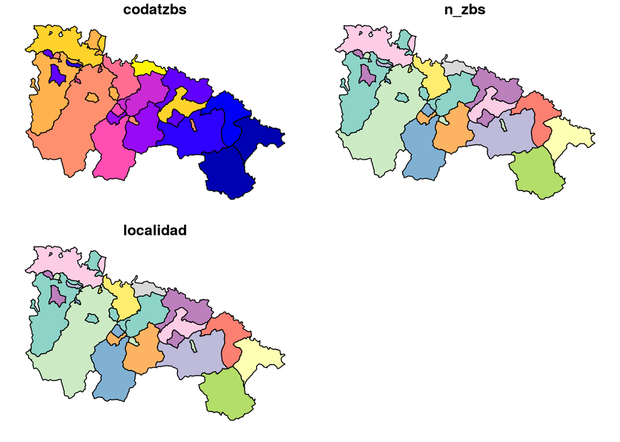

```r
plot(rioja_zonas_basicas_shp)
```

```r
# Este mapa no parece bien...

# tmap object
mapa_casos_activos_zonas_basicas2 <-

    tm_shape(rioja_zonas_basicas_shp) +
    tm_polygons(id          = "localidad",
                # col         = "numberOfFloorsAboveGround",
                border.col  = "blue",
                # palette     = col.spec.fun(15),
                alpha       = 0.5,
                legend.show = FALSE,
                textNA      = "Sin datos",
                title       = "Localidad") +

    # tm_shape(rioja_casos_activos_zonas_basicas_shp) +
    # tm_dots("casos_activos")

    tm_shape(rioja_casos_activos_zonas_basicas_shp) +
    tm_dots(# id   = "localidad",
            title = "casos activos",
            size  = "casos_activos",
            id    = "casos_activos"
            )


# dynamic map
tmap_leaflet(mapa_casos_activos_zonas_basicas2)
```

[interactive chart not shown]

## Resumen diario

Guardamos el resumen diario

```r
saveRDS(resumen_diario, file = paste0('./data/resumen_diario_', Sys.Date(),'.rds'))
```

# Datos de ISCIII

## Serie historica

Los datos de (ISCIII)[https://covid19.isciii.es/]

```r
link_isciii <- 'https://covid19.isciii.es/resources/serie_historica_acumulados.csv'
```

En los datos en local se han eliminado las últimas filas que corresponden a comentarios.

```r
# Datos en local
serie_historica_acumulados_isciii <- read_csv("data/serie_historica_acumulados.csv",
                                              locale = locale(date_names = "es"))
```

```r
# Directamente de Internet
serie_historica_acumulados_isciii <- read_csv(link_isciii,
                                              locale = locale(date_names = "es"))
```

Vemos los datos por CC.AA.

```r
table(serie_historica_acumulados_isciii$CCAA, useNA = 'ifany')
```

[output not shown]

[output cut: 39 more lines]

Comunidades autónomas

```r
serie_historica_acumulados_isciii$CCAA <- factor(serie_historica_acumulados_isciii$CCAA,
                                                 levels = c('AN', 'AR', 'AS', 'CB', 'CE',
                                                            'CL', 'CM', 'CN', 'CT', 'EX',
                                                            'GA', 'IB', 'MC', 'MD', 'ML',
                                                            'NC', 'PV', 'RI', 'VC'),
                                                 labels = c('Andalucía', 'Aragón',
                                                            'Asturias, Principado de',
                                                            'Cantabria', 'Ceuta',
                                                            'Castilla y León',
                                                            'Castilla - La Mancha',
                                                            'Canarias', 'Cantabria',
                                                            'Extremadura',
                                                            'Galicia', 'Balears, Illes',
                                                            'Murcia, Región de',
                                                            'Madrid, Comunidad de',
                                                            'Melilla',
                                                            'Navarra, Comunidad Foral de',
                                                            'País Vasco', 'Rioja, La',
                                                            'Comunitat Valenciana'))
```

Pasamos la fecha a formato *Date*

```r
serie_historica_acumulados_isciii$FECHA <- as.Date(serie_historica_acumulados_isciii$FECHA, "%d/%m/%Y")
```

```r
summary(serie_historica_acumulados_isciii)
```

```
##                       CCAA         FECHA                CASOS
##  Cantabria              :152   Min.   :2020-02-20   Min.   :    0.00
##  Andalucía              : 76   1st Qu.:2020-03-09   1st Qu.:   28.75
##  Aragón                 : 76   Median :2020-03-28   Median :  679.00
##  Asturias, Principado de: 76   Mean   :2020-03-28   Mean   : 3688.81
##  Ceuta                  : 76   3rd Qu.:2020-04-16   3rd Qu.: 3225.00
##  (Other)                :988   Max.   :2020-05-05   Max.   :54853.00
##  NA's                   :  8   NA's   :8            NA's   :508
##       PCR+        TestAc+        Hospitalizados       UCI
##  Min.   :    0   Mode :logical   Min.   :    0   Min.   :   0.0
##  1st Qu.: 1874   FALSE:24        1st Qu.:  156   1st Qu.:  14.0
##  Median : 3980   NA's :1428      Median :  984   Median : 105.5
##  Mean   :11182                   Mean   : 3033   Mean   : 293.9
##  3rd Qu.:12199                   3rd Qu.: 3107   3rd Qu.: 308.0
##  Max.   :63416                   Max.   :41031   Max.   :3465.0
##  NA's   :981                     NA's   :348     NA's   :314
##    Fallecidos      Recuperados
##  Min.   :   0.0   Min.   :    0.00
##  1st Qu.:   8.0   1st Qu.:   18.25
##  Median : 135.0   Median :  475.00
##  Mean   : 658.8   Mean   : 2550.53
##  3rd Qu.: 555.0   3rd Qu.: 1963.00
##  Max.   :8466.0   Max.   :38331.00
##  NA's   :331      NA's   :350
```

### Nuevas columnas

```r
# Valores diarios
serie_historica_acumulados_isciii <- serie_historica_acumulados_isciii %>%
  group_by(CCAA) %>%
  arrange(FECHA) %>%
  mutate(diario_hospitalizados = Hospitalizados - lag(Hospitalizados, order_by = FECHA),
         diario_uci            = UCI - lag(UCI, order_by = FECHA),
         diario_fallecidos     = Fallecidos - lag(Fallecidos, order_by = FECHA)
         # diario_recuperados    = Recuperados - lag(Recuperados) # Este es acumulado
  )
```

Guardamos

```r
saveRDS(serie_historica_acumulados_isciii, file = paste0('./data/serie_historica_acumulados_isciii_', Sys.Date(),'.rds'))
```

## MoMo ISCIII

Los modelos [MoMo del ISCIII](https://momo.isciii.es/public/momo/dashboard/momo_dashboard.html#nacional).

Los datos están disponibles [aquí](https://momo.isciii.es/public/momo/data) en formato CSV, y se actualizan diariamente. Son las series temporales con los resultados de MoMo para ámbito nacional y de comunidades autónomas, en diferentes grupos poblacionales, durante los últimos dos años. Consta de las siguientes columnas:

```
ambito: nacional o ccaa
cod_ambito: si es nacional, viene vacío. Si es una comunidad autónoma, trae su código ISO 3166-2.
cod_ine_ambito: columna informativa sobre la comunidad autónoma, si aplica. Es su código INE.
nombre_ambito: columna informativa sobre la comunidad autónoma, si aplica. Es su nombre.
cod_sexo: código INE del sexo. 1 para hombres, 6 para mujeres.
nombre_sexo: columna informativa sobre el sexo. Su nombre descriptivo (hombres, mujeres).
cod_gedad: código del grupo de edad. Los posibles son: menos_65, 65_74, mas_74.
nombre_gedad: columna informativa sobre el grupo de edad. Su nombre descriptivo (p.e. edad < 65).
fecha_defuncion: la fecha a la que se refieren los indicadores descritos de aquí en adelante. Es la fecha en la que ocurre la defunción.
defunciones_observadas: el número de defunciones observadas (incluye la corrección por retraso).
defunciones_observadas_lim_inf: el límite inferior del invervalo de confianza de las defunciones observadas (debido a la corrección).
defunciones_observadas_lim_sup: de forma equivalente, el límite superior.
defunciones_esperadas: el número de defunciones esperadas, resultantes del modelo.
defunciones_esperadas_q01: el límite inferior del intervalo de confianza de las defunciones esperadas, correspondiente al percentil 1 de la distribución.
defunciones_esperadas_q99: de forma equivalente, el límite superior, al percentil 99.
```

Las series vienen agregadas por ámbito, código de ámbito, sexo, grupo de edad y fecha de defunción. Nótese que las series que son agregados del resto vienen en otra serie aparte. P.e., si se quiere elegir la serie de toda la población (nacional, todos los sexos, todas las edades), hay que filtrar por ambito=“nacional”, cod_sexo=“all” y cod_gedad=“all”.

Los datos aquí descargados se refieren a las defunciones por todas las causas notificadas por los registros civiles informatizados de los municipios correspondientes. Para saber más, consulta las pestañas de “Documentación” y “Notificación”.

Nota: los datos cambian de forma retroactiva, especialmente en los días más recientes. Lo que hoy puedes descargar (o consultar en este portal) mañana puede tener indicadores diferentes en fechas pasadas. El motivo es el retraso en la notificación, detallado en la sección de [Documentación](https://momo.isciii.es/public/momo/dashboard/momo_dashboard.html#documentacion).

```r
link_momo <- 'https://momo.isciii.es/public/momo/data'
```

```r
# Los datos en local
data <- read_csv("data/data.csv", col_types = cols(cod_ambito = col_character(),
    cod_ine_ambito = col_character(), nombre_ambito = col_character()),
    locale = locale(date_names = "es", encoding = "ISO-8859-1"))
```

```r
summary(data)
```

```r
# Directamente de Internet
# momo_isciii <- read_csv(link_momo, locale = locale(date_names = "es"))
# momo_isciii <- read_delim(link_momo, ",", escape_double = FALSE,
#                           # col_names = FALSE,
#                           locale = locale(date_names = "es",
#                                           decimal_mark = ",",
#                                           grouping_mark = "."),
#                           trim_ws = TRUE)
momo_isciii <- read_csv(link_momo, col_types = cols(cod_ambito = col_character(),
    cod_ine_ambito = col_character(), nombre_ambito = col_character()),
    locale = locale(date_names = "es", encoding = "UTF-8"))
```

### ETL

Pasamos algunos valores a factor

```r
momo_isciii$ambito          <- as.factor(momo_isciii$ambito)
momo_isciii$cod_ambito      <- as.factor(momo_isciii$cod_ambito)
momo_isciii$cod_ine_ambito  <- as.factor(momo_isciii$cod_ine_ambito)
momo_isciii$nombre_ambito   <- as.factor(momo_isciii$nombre_ambito)
momo_isciii$cod_sexo        <- as.factor(momo_isciii$cod_sexo)
momo_isciii$nombre_sexo     <- as.factor(momo_isciii$nombre_sexo)
momo_isciii$cod_gedad       <- as.factor(momo_isciii$cod_gedad)
momo_isciii$nombre_gedad    <- as.factor(momo_isciii$nombre_gedad)
```

```r
summary(momo_isciii)
```

```
##       ambito         cod_ambito     cod_ine_ambito
##  ccaa    :170772   AN     :  8988   1      :  8988
##  nacional:  8988   AR     :  8988   10     :  8988
##                    AS     :  8988   11     :  8988
##                    CB     :  8988   12     :  8988
##                    CE     :  8988   13     :  8988
##                    (Other):125832   (Other):125832
##                    NA's   :  8988   NA's   :  8988
##                  nombre_ambito    cod_sexo     nombre_sexo       cod_gedad
##  Andalucía              :  8988   1  :59920   hombres:59920   65_74   :44940
##  Aragón                 :  8988   6  :59920   mujeres:59920   all     :44940
##  Asturias, Principado de:  8988   all:59920   todos  :59920   mas_74  :44940
##  Balears, Illes         :  8988                               menos_65:44940
##  Canarias               :  8988
##  (Other)                :125832
##  NA's                   :  8988
##      nombre_gedad   fecha_defuncion      defunciones_observadas
##  edad < 65 :44940   Min.   :2018-04-19   Min.   :   0.00
##  edad > 75 :44940   1st Qu.:2018-10-23   1st Qu.:   2.00
##  edad 65-74:44940   Median :2019-04-28   Median :   8.00
##  todos     :44940   Mean   :2019-04-28   Mean   :  36.84
##                     3rd Qu.:2019-11-01   3rd Qu.:  27.00
##                     Max.   :2020-05-06   Max.   :2466.00
##
##  defunciones_observadas_lim_inf defunciones_observadas_lim_sup
##  Min.   :   0.00                Min.   :   0.00
##  1st Qu.:   2.00                1st Qu.:   2.00
##  Median :   8.00                Median :   8.00
##  Mean   :  36.81                Mean   :  36.87
##  3rd Qu.:  27.00                3rd Qu.:  27.00
##  Max.   :2466.00                Max.   :2466.00
##
##  defunciones_esperadas defunciones_esperadas_q01 defunciones_esperadas_q99
##  Min.   :   0.00       Min.   :   0.00           Min.   :   0.00
##  1st Qu.:   2.00       1st Qu.:   0.00           1st Qu.:   6.31
##  Median :   8.00       Median :   2.69           Median :  15.00
##  Mean   :  36.04       Mean   :  27.30           Mean   :  47.53
##  3rd Qu.:  26.50       3rd Qu.:  16.14           3rd Qu.:  38.62
##  Max.   :1325.00       Max.   :1174.28           Max.   :1691.27
##
```

Esto lo necesitamos para “traducir” los códigos

```r
table(momo_isciii$cod_ambito, momo_isciii$nombre_ambito)
```

```
##
##      Andalucía Aragón Asturias, Principado de Balears, Illes Canarias Cantabria
##   AN      8988      0                       0              0        0         0
##   AR         0   8988                       0              0        0         0
##   AS         0      0                    8988              0        0         0
##   CB         0      0                       0              0        0      8988
##   CE         0      0                       0              0        0         0
##   CL         0      0                       0              0        0         0
##   CM         0      0                       0              0        0         0
##   CN         0      0                       0              0     8988         0
##   CT         0      0                       0              0        0         0
##   EX         0      0                       0              0        0         0
##   GA         0      0                       0              0        0         0
##   IB         0      0                       0           8988        0         0
##   MC         0      0                       0              0        0         0
##   MD         0      0                       0              0        0         0
##   ML         0      0                       0              0        0         0
##   NC         0      0                       0              0        0         0
##   PV         0      0                       0              0        0         0
##   RI         0      0                       0              0        0         0
##   VC         0      0                       0              0        0         0
##
##      Castilla - La Mancha Castilla y León Cataluña Ceuta Comunitat Valenciana
##   AN                    0               0        0     0                    0
##   AR                    0               0        0     0                    0
##   AS                    0               0        0     0                    0
##   CB                    0               0        0     0                    0
##   CE                    0               0        0  8988                    0
##   CL                    0            8988        0     0                    0
##   CM                 8988               0        0     0                    0
##   CN                    0               0        0     0                    0
##   CT                    0               0     8988     0                    0
##   EX                    0               0        0     0                    0
##   GA                    0               0        0     0                    0
##   IB                    0               0        0     0                    0
##   MC                    0               0        0     0                    0
##   MD                    0               0        0     0                    0
##   ML                    0               0        0     0                    0
##   NC                    0               0        0     0                    0
##   PV                    0               0        0     0                    0
```

[output cut: 29 more lines]

```
##   CE                           0          0         0
##   CL                           0          0         0
##   CM                           0          0         0
##   CN                           0          0         0
##   CT                           0          0         0
##   EX                           0          0         0
##   GA                           0          0         0
##   IB                           0          0         0
##   MC                           0          0         0
##   MD                           0          0         0
##   ML                           0          0         0
##   NC                        8988          0         0
##   PV                           0       8988         0
##   RI                           0          0      8988
##   VC                           0          0         0
```

Guardamos

```r
saveRDS(momo_isciii, file = paste0('./data/momo_isciii_', Sys.Date(),'.rds'))
```